# Automated detection of route divergence

**Part 2: model prototyping**

## Introduction

Cabify prices a journey before it happens, from the distance and duration that the routing engine predicts. If the driver ends up following a noticeably different route, the price was calculated on a trip that never took place. At the volumes involved, checking this by hand is not an option, so the question is whether a model can take it over.

We have a labelling exercise to work from. A sample of journeys was drawn, each one plotted as two overlaid polylines (the estimated route in black, the real one in magenta), and annotators were asked to say whether the two were the same, whether they differed, or whether they could not tell. The result is `challenge_dataset.json`, with one record per annotator judgement.

The plan is the usual one. Understand how the annotators behaved, settle on a target variable, turn each pair of routes into numbers, get a baseline working, then widen the search properly before deciding what to keep. After that, assess whether the result is good enough to be worth using, choose an operating point, and write down what the team taking this to production needs to know.

One thing is worth saying at the outset, because it shapes every choice that follows. We are not building a model of whether two polylines are geometrically identical. That question has a closed-form answer and would not need annotators. We are building a model of **what a person would say when shown the two routes on a map**, which is a subjective target measured with noise. That distinction will come back more than once.

## 1. Data preparation and annotation review

Before touching any geometry, it is worth understanding the labels, since they are the thing we will be trying to reproduce.

Two practical points about the file. First, the full coordinate lists are repeated on every annotation row, so a journey judged by three people appears three times, and the routes have to be deduplicated before any modelling. Second, a handful of journeys were shown to the same annotator more than once, so a single vote per annotator per journey has to be resolved first.

I also tag each journey with its nearest Cabify city. Not to use as an input to the model, but so that later on I can check whether anything I build depends on where it was measured.

```python
import json, os, time, warnings
from pathlib import Path
from itertools import combinations
import numpy as np, pandas as pd
import matplotlib.pyplot as plt
from sklearn.model_selection import StratifiedKFold, GroupKFold
from sklearn.linear_model import LogisticRegression
from sklearn.ensemble import HistGradientBoostingClassifier
from sklearn.pipeline import make_pipeline, Pipeline
from sklearn.preprocessing import StandardScaler
from sklearn.metrics import (roc_auc_score, average_precision_score, roc_curve,
                             precision_recall_curve, brier_score_loss, confusion_matrix,
                             f1_score, accuracy_score)
from sklearn.inspection import permutation_importance
from je_style import *
import p2_lib as L

warnings.filterwarnings("ignore")
set_style()
BASE = Path.cwd()                 # run this notebook from its own folder
DATA_DIR, FIG_DIR, MODEL_DIR = BASE / "Data", BASE / "Figures", BASE / "Model"
FIG_DIR.mkdir(exist_ok=True)
MODEL_DIR.mkdir(exist_ok=True)
PATH = DATA_DIR / "challenge_dataset.json"
```

```python
raw = json.load(open(PATH))
ann_raw = pd.DataFrame([{k: r[k] for k in ("journey_id", "annotator", "annotation")} for r in raw])
routes = {}
for r in raw:
    routes.setdefault(r["journey_id"], (r["estimated_route"], r["real_route"]))
print(f"{len(ann_raw):,} annotation rows | {ann_raw.journey_id.nunique():,} journeys | "
      f"{ann_raw.annotator.nunique()} annotators")

# the same annotator judged some journeys twice -> test-retest reliability
dup = ann_raw.groupby(["journey_id", "annotator"])["annotation"].agg(["size", "nunique"])
N_REPEAT = int((dup["size"] > 1).sum())
SELF_CONSISTENCY = float((dup.loc[dup["size"] > 1, "nunique"] == 1).mean())
print(f"{N_REPEAT} journeys were re-judged by the same annotator | "
      f"they agreed with themselves {SELF_CONSISTENCY:.1%} of the time")


def modal(s):
    vc = s.value_counts()
    return vc.index[0] if len(vc) == 1 or vc.iloc[0] > vc.iloc[1] else L.IDK


ann = (ann_raw.groupby(["journey_id", "annotator"])["annotation"]
       .agg(modal).reset_index())          # one vote per annotator per journey

city = pd.Series({j: L.assign_city(*routes[j][0][0]) for j in routes}, name="city")
print(f"{city.nunique()} cities | top: "
      + ", ".join(f"{c} {n}" for c, n in city.value_counts().head(5).items()))
```

```
3,027 annotation rows | 2,386 journeys | 8 annotators
122 journeys were re-judged by the same annotator | they agreed with themselves 88.5% of the time
```

```
28 cities | top: Buenos Aires 627, Bogotá 524, Santiago 283, Madrid 270, Lima 256
```

```python
g = ann.groupby("journey_id")["annotation"]
lab = pd.DataFrame({
    "n_ann": g.size(),
    "n_same": g.apply(lambda s: (s == L.SAME).sum()),
    "n_diff": g.apply(lambda s: (s == L.DIFF).sum()),
    "n_idk": g.apply(lambda s: (s == L.IDK).sum()),
}).join(city)
# "I don't know" is not a missing value, it is a declared inability to decide.
# It contributes half a vote to each side instead of being erased.
lab["p_decisive"] = lab.n_diff / (lab.n_diff + lab.n_same).replace(0, np.nan)  # decisive votes only
lab["p_differ"] = (lab.n_diff + 0.5 * lab.n_idk) / lab.n_ann                   # target used for training
lab["weight"] = lab.n_ann.astype(float)                                        # evidence behind the label
lab["majority"] = np.where(lab.n_diff > lab.n_same, 1.0,
                    np.where(lab.n_same > lab.n_diff, 0.0, np.nan))
lab["multi"] = lab.n_ann >= 2
lab["split"] = lab.multi & lab.p_decisive.between(0.001, 0.999)
lab["group"] = np.where(~lab.multi, "single annotator",
                 np.where(lab.split, "2+ and split", "2+ and unanimous"))
softened = int(((lab.n_idk > 0) & lab.majority.notna()).sum())
rescued = int(lab.majority.isna().sum())
print(f"target: all {len(lab):,} journeys now carry a label")
print(f"  {softened} had an 'I don't know' vote that would otherwise have been erased")
print(f"  {rescued} had no usable label at all (all-IDK or tied), they enter at p = 0.5")

ds_p, ds_rel = L.dawid_skene(ann)
lab["ds_p_differ"] = ds_p

print(f"journeys with >1 annotator: {lab.multi.sum():,} ({lab.multi.mean():.0%}) | "
      f"of those, split: {lab.loc[lab.multi,'split'].mean():.1%}")
print(f"usable target (decisive majority): {lab.majority.notna().sum():,} | "
      f"ties {int(((lab.n_same == lab.n_diff) & (lab.n_same > 0)).sum())} | "
      f"all-'I don't know' {int(((lab.n_same == 0) & (lab.n_diff == 0)).sum())}")

# inter-annotator agreement, over every pair that judged the same journey
pa = []
for _, s in ann[ann.journey_id.isin(lab.index[lab.multi])].groupby("journey_id")["annotation"]:
    for a, b in combinations(s.tolist(), 2):
        if a != L.IDK and b != L.IDK:
            pa.append(a == b)
PAIR_AGREE = float(np.mean(pa))
pm = ann.loc[ann.annotation != L.IDK, "annotation"].value_counts(normalize=True)
pe = float((pm ** 2).sum())
KAPPA = (PAIR_AGREE - pe) / (1 - pe)
print(f"inter-annotator agreement: {PAIR_AGREE:.1%} over {len(pa):,} pairs | kappa {KAPPA:.3f}")
```

```
target: all 2,386 journeys now carry a label
  57 had an 'I don't know' vote that would otherwise have been erased
  174 had no usable label at all (all-IDK or tied), they enter at p = 0.5
journeys with >1 annotator: 489 (20%) | of those, split: 6.5%
usable target (decisive majority): 2,212 | ties 30 | all-'I don't know' 144
inter-annotator agreement: 92.7% over 478 pairs | kappa 0.850
```

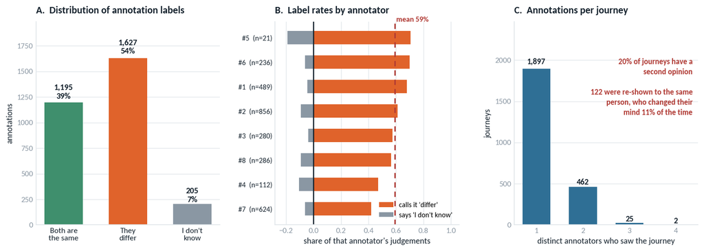

```python
fig, axes = plt.subplots(1, 3, figsize=(14.2, 4.4), gridspec_kw=dict(wspace=0.30))
ax = axes[0]
vc = ann_raw.annotation.value_counts().reindex([L.SAME, L.DIFF, L.IDK])
ax.bar(range(3), vc.values, color=[GREEN, ORANGE, MUTED], width=.6)
for i, v in enumerate(vc.values):
    ax.text(i, v * 1.02, f"{v:,}\n{v/len(ann_raw):.0%}", ha="center", va="bottom",
            fontsize=10, weight="bold", color=INK, linespacing=1.25)
ax.set_xticks(range(3), ["Both are\nthe same", "They\ndiffer", "I don't\nknow"], fontsize=9.5)
ax.tick_params(axis="x", labelcolor=INK)
ax.set_ylim(0, vc.max() * 1.22); ax.set_ylabel("annotations")
ax.grid(axis="x", visible=False)
ax.set_title("A.  Distribution of annotation labels", pad=10)

ax = axes[1]
rate = ann[ann.annotation != L.IDK].groupby("annotator")["annotation"].apply(
    lambda s: (s == L.DIFF).mean()).sort_values()
idk = ann.groupby("annotator")["annotation"].apply(lambda s: (s == L.IDK).mean())[rate.index]
n_by = ann.groupby("annotator").size()[rate.index]
ax.barh(range(len(rate)), rate.values, color=ORANGE, height=.55, label="calls it 'differ'")
ax.barh(range(len(idk)), -idk.values, color=MUTED, height=.55, label="says 'I don't know'")
ax.axvline(0, color=INK, lw=1.4)
ax.axvline(rate.mean(), color=RED, lw=1.6, ls=(0, (4, 3)))
ax.text(rate.mean() + .012, len(rate) - .35, f"mean {rate.mean():.0%}", fontsize=9,
        color=RED, weight="bold")
ax.set_yticks(range(len(rate)), [f"#{a}  (n={n_by[a]})" for a in rate.index], fontsize=8.8)
ax.tick_params(axis="y", labelcolor=INK)
ax.set_xlabel("share of that annotator's judgements")
ax.set_xlim(-.28, 1.06)
ax.grid(axis="y", visible=False); ax.legend(loc="lower right", fontsize=8.6)
ax.set_title("B.  Label rates by annotator", pad=10)

ax = axes[2]
cnt = lab.n_ann.value_counts().sort_index()
ax.bar(cnt.index, cnt.values, color=BLUE, width=.6)
for x, v in cnt.items():
    ax.text(x, v * 1.02, f"{v:,}", ha="center", va="bottom", fontsize=9.6, weight="bold", color=INK)
ax.set_xticks(cnt.index)
ax.set_xlabel("distinct annotators who saw the journey"); ax.set_ylabel("journeys")
ax.set_ylim(0, cnt.max() * 1.30)
ax.grid(axis="x", visible=False)
ax.text(.97, .82, f"{lab.multi.mean():.0%} of journeys have a\nsecond opinion\n\n"
                  f"{N_REPEAT} were re-shown to the same\nperson, who changed their\n"
                  f"mind {1-SELF_CONSISTENCY:.0%} of the time",
        transform=ax.transAxes, ha="right", va="top", fontsize=9.3, color=RED,
        weight="bold", linespacing=1.45)
ax.set_title("C.  Annotations per journey", pad=10)
fig.savefig(f"{FIG_DIR}/A_annotation_review.png")
plt.show()
plt.show()
```

Four things stand out, and three of them are about the labelling process rather than the routes.

**The classes are close to balanced.** 54% of judgements say the routes differ and 39% say they match, which is a healthier starting point than most classification problems and means accuracy is a reasonable metric to quote alongside the ranking ones.

**"I don't know" is 7% of judgements.** It is tempting to read this as missing data. I do not think it is: it marks pairs that sat near that annotator's decision boundary, which is information about the journey, not an absence of information. What to do with it is the first real decision to make.

**Most journeys were seen once.** Only 20% have a second opinion and just 27 were seen by three or more people, so the consensus we will be comparing against is thin.

And then the number I did not expect to find. 122 journeys were shown to the same annotator twice, and that person changed their own answer 11.5% of the time. This is worth holding on to, because it gives us something concrete to measure a model against later, without any reference to disagreements between different people.

## 2. Target variable definition

The annotations disagree, so we have to decide what `y` is. There are several defensible answers and they are not equivalent, so this is worth doing carefully rather than by reflex.

Start with what is actually in the data. Of the 489 journeys with two or more distinct annotators, 227 are a unanimous "differ", 149 a unanimous "same", 30 are genuine disagreements, and the rest involve at least one "I don't know". Because most of these journeys have exactly two annotators, **any disagreement is automatically a tie**. There is no 2 to 1 majority to fall back on, since that would need three annotators and only 27 journeys have them.

That reframes the usual options:

| Strategy | Journeys kept | What it gets right | What it costs |
| --- | --- | --- | --- |
| Unanimous, 2+ annotators | 457 | The cleanest possible signal | Throws away 81% of the data, and specifically the harder cases |
| Majority vote, ties dropped | 2,212 | Standard and easy to explain | Treats a single unconfirmed vote as equal in authority to two agreeing ones |
| Any 'differ' | 2,386 | Conservative, defensible if a mispriced fare costs far more than a review | Inherits the strictest annotator's threshold |
| Soft label | 2,386 | Keeps everything, carries the uncertainty forward | Needs a learner that accepts sample weights |

I use the soft label, with two details that matter.

**"I don't know" contributes half a vote to each side** rather than being dropped from the count. Dropping it is not neutral: a journey with one "differ" and one "I don't know" would otherwise score a fully confident 1.0, exactly the same label as a journey where two people agreed it differed. That is clearly wrong, since one of the two people who looked at it could not decide. 57 journeys are affected. A further 174 (144 where every annotator said "I don't know", plus the 30 ties) would have had no label at all and would have dropped out of training entirely, which quietly assumes they are missing at random. They are not: they are the ambiguous ones.

**The label carries the direction and the weight carries the evidence.** A journey seen by three people counts three times as heavily as one seen by a single annotator, which is the honest way to express that we know more about it.

```
lab["p_differ"] = (lab.n_diff + 0.5 * lab.n_idk) / lab.n_ann
lab["weight"]   = lab.n_ann
```

Training on a continuous target is then just weighted cross-entropy, which we can write as each journey entering twice, once as a positive with weight `p_differ` and once as a negative with weight `1 - p_differ`. It is not an approximation, it is the same objective.

For **evaluation** I keep the majority vote, restricted to the 2,212 journeys where one exists. That is the interpretable business definition, and scoring against soft labels would flatter the model. So the ambiguous journeys train it but are never used to grade it.

Alongside this it is worth checking whether the annotators can be weighted by how reliable they are, using a Dawid-Skene model: a latent binary truth per journey, and a 2 by 3 confusion matrix per annotator, fitted by EM. Modelling "I don't know" as a third emitted category (rather than a dropped row) means an annotator who abstains often is treated as noisy rather than as having fewer observations.

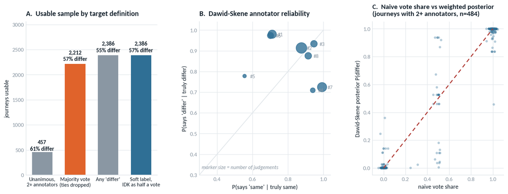

```python
fig, axes = plt.subplots(1, 3, figsize=(14.2, 4.6), gridspec_kw=dict(wspace=0.32))
ax = axes[0]
uni = lab.multi & ~lab.split
strat = {
    "Unanimous,\n2+ annotators": (int(uni.sum()), float(lab.loc[uni, "p_decisive"].mean())),
    "Majority vote\n(ties dropped)": (int(lab.majority.notna().sum()), float(lab.majority.mean())),
    "Any 'differ'": (len(lab), float((lab.n_diff > 0).mean())),
    "Soft label,\nIDK as half a vote": (len(lab), float(lab.p_differ.mean())),
}
names = list(strat); kept = [strat[k][0] for k in names]; pos = [strat[k][1] for k in names]
ax.bar(range(4), kept, color=[MUTED, ORANGE, MUTED, BLUE], width=.62)
for i, (k, p) in enumerate(zip(kept, pos)):
    ax.text(i, k * 1.02, f"{k:,}\n{p:.0%} differ", ha="center", va="bottom", fontsize=9.4,
            weight="bold", color=INK, linespacing=1.3)
ax.set_xticks(range(4), names, fontsize=9)
ax.tick_params(axis="x", labelcolor=INK)
ax.set_ylabel("journeys usable"); ax.set_ylim(0, max(kept) * 1.28)
ax.grid(axis="x", visible=False)
ax.set_title("A.  Usable sample by target definition", pad=10)

ax = axes[1]
rel = ds_rel.merge(n_by.rename("n"), left_on="annotator", right_index=True)
ax.scatter(rel.p_same_correct, rel.p_differ_correct, s=28 + rel.n / 3, color=BLUE,
           alpha=.8, zorder=3)
for _, r in rel.iterrows():
    ax.annotate(f"#{int(r.annotator)}", (r.p_same_correct, r.p_differ_correct),
                textcoords="offset points", xytext=(9, -3), fontsize=8.6, color=MUTED)
ax.plot([0, 1], [0, 1], color=GRID, lw=1.2, zorder=1)
ax.set_xlabel("P(says 'same' | truly same)"); ax.set_ylabel("P(says 'differ' | truly differ)")
ax.set_xlim(.3, 1.04); ax.set_ylim(.3, 1.04)
ax.text(.02, .04, "marker size = number of judgements", transform=ax.transAxes,
        fontsize=8.6, color=MUTED, style="italic")
ax.set_title("B.  Dawid-Skene annotator reliability", pad=10)

ax = axes[2]
m = lab[lab.multi].dropna(subset=["p_decisive"])
rng = np.random.default_rng(0)
ax.scatter(m.p_decisive + rng.normal(0, .015, len(m)), m.ds_p_differ,
           s=16, alpha=.35, color=BLUE, edgecolors="none")
ax.plot([0, 1], [0, 1], color=RED, lw=1.6, ls=(0, (4, 3)))
ax.set_xlabel("naive vote share"); ax.set_ylabel("Dawid-Skene posterior P(differ)")
ax.set_title(f"C.  Naive vote share vs weighted posterior\n(journeys with 2+ annotators, n={len(m):,})",
             pad=10, fontsize=11.5)
fig.savefig(f"{FIG_DIR}/B_target_definition.png")
plt.show()
plt.show()
```

The reliability estimates are more interesting than the aggregation choice. The spread is not really a "good annotators and bad annotators" axis, it is a severity axis: some annotators almost never call two identical routes different but miss a quarter of the real divergences, and others are the mirror image. Panel C shows the consequence on the journeys where people disagreed.

That said, reweighting flips the majority on almost nothing. With 80% of journeys carrying a single vote, and with every annotator's estimated reliability comfortably above the prior odds, the posterior almost never crosses 0.5. I would treat this as a diagnostic that tells us something real about the panel, rather than as the production label.

## 3. Feature engineering

Everything below is computed from the two coordinate lists alone. Coordinates are projected to metres with a local equirectangular projection centred on each route, so every distance comes out directly interpretable. At city scale the distortion is well under 0.1%, far below the annotation noise we already know about.

The features fall into eight groups, each one an attempt to capture a different way two routes can look different to a person:

1. **Scale.** Length of each route, their ratio, the detour ratio. Catches "the driver went the long way round".
2. **Endpoints.** Start and end gaps, which catch the qualitatively different failure of the two routes not even connecting the same places.
3. **Distance profile.** Mean, median, p90 and max of the pointwise separation, symmetrised in both directions (the max being the Hausdorff distance). These are computed point to *segment* rather than point to point, so the values do not depend on how densely each route happens to be sampled, which matters here because point counts run from 5 to 1,886.
4. **Overlap fractions** at 10, 25, 50, 100 and 200 m. This is the closest thing to what the eye does when it looks at the two lines.
5. **Sustained detour.** Longest contiguous stretch more than 30 m off, how many such episodes, total deviated fraction. This group is an attempt to encode human perception rather than average error: a route that sits 40 m off along its whole length looks the same to a person, while a route that is perfect except for one four-block detour looks different. Mean distance cannot separate those two. A longest-run statistic can.
6. **Curve similarity.** Discrete Frechet and DTW, on arc-length-resampled 40-point versions so the dynamic programmes stay cheap.
7. **Shape.** Bearing profile differences and bounding-box IoU.
8. **Normalisation.** Every distance also appears divided by route length, because a 200 m deviation on a 1 km trip is a different event from the same deviation on a 20 km trip.

City is deliberately left out. Giving it to the model would let it learn per-city label prevalences instead of geometry.

```python
t0 = time.time()
feat = pd.DataFrame([{"journey_id": j, **L.route_features(e, r)} for j, (e, r) in routes.items()]
                    ).set_index("journey_id")
print(f"{feat.shape[1]} features for {len(feat):,} journeys in {time.time()-t0:.0f}s")
D = feat.join(lab)
FEATS = list(feat.columns)

gold = D.dropna(subset=["majority"]).copy()     # decisive majority, this is what we score against
extra = D[D.majority.isna()].copy()            # ambiguous, used for training only, never scored
X, y = gold[FEATS].to_numpy(), gold["majority"].to_numpy().astype(int)
p_soft, w_evid = gold["p_differ"].to_numpy(), gold["weight"].to_numpy()
Xx, px, wx = extra[FEATS].to_numpy(), extra["p_differ"].to_numpy(), extra["weight"].to_numpy()
groups = gold["city"].to_numpy()
print(f"scoreable set: {X.shape[0]:,} journeys x {X.shape[1]} features | "
      f"{y.mean():.1%} labelled 'they differ'")
print(f"plus {len(Xx):,} ambiguous journeys that train the model but cannot be scored")
```

```
34 features for 2,386 journeys in 17s
scoreable set: 2,212 journeys x 34 features | 57.4% labelled 'they differ'
plus 174 ambiguous journeys that train the model but cannot be scored
```

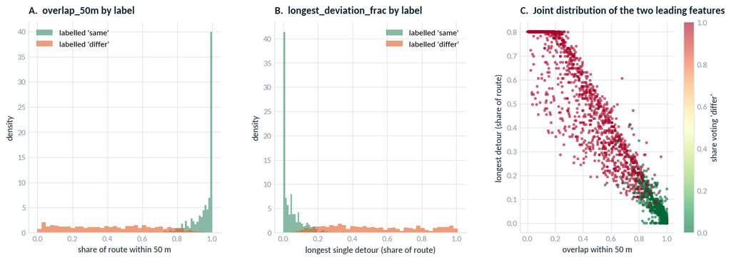

```python
fig, axes = plt.subplots(1, 3, figsize=(14.2, 4.4), gridspec_kw=dict(wspace=0.28))
for ax, (c, lb, ttl) in zip(axes[:2], [
        ("overlap_50m", "share of route within 50 m", "A."),
        ("longest_deviation_frac", "longest single detour (share of route)", "B.")]):
    for v, col, nm in [(0, GREEN, "labelled 'same'"), (1, ORANGE, "labelled 'differ'")]:
        ax.hist(gold.loc[y == v, c], bins=40, alpha=.62, color=col, label=nm, density=True)
    ax.set_xlabel(lb); ax.set_ylabel("density"); ax.legend()
    ax.set_title(f"{ttl}  {c} by label", pad=10)
ax = axes[2]
sc = ax.scatter(gold["overlap_50m"], gold["longest_deviation_frac"].clip(0, .8),
                c=gold["p_decisive"], cmap="RdYlGn_r", s=11, alpha=.6, edgecolors="none")
plt.colorbar(sc, ax=ax, label="share voting 'differ'")
ax.set_xlabel("overlap within 50 m"); ax.set_ylabel("longest detour (share of route)")
ax.set_title("C.  Joint distribution of the two leading features", pad=10)
fig.savefig(f"{FIG_DIR}/C_feature_separation.png")
plt.show()
plt.show()
```

About 9 ms per journey, so the whole dataset in around 20 seconds on one core. A full day of Cabify volume would be a few CPU-minutes, which is cheap enough to run inline rather than as a batch job.

Panel C is the useful picture. Two of these features (how much of the route overlaps, and how long the single worst detour is) already carve out most of the separation between the two classes, with the disagreement concentrated in a thin band along the boundary rather than scattered through the space.

## 4. Baseline models

Three things I want to be careful about here.

**One row per journey.** Since the file repeats coordinates across annotation rows, training on it as delivered would put the same journey in both the training and the test fold and inflate everything.

**Baselines worth beating.** A single geometric threshold on the overlap-within-50 m feature, and a logistic regression on the standardised features. If a gradient booster cannot beat a one-line rule, that is worth knowing before anyone deploys it.

**Out-of-fold reporting only**, on 5-fold stratified splits. Nothing in this notebook is scored on data the model saw.

I also want to check what the decision about "I don't know" from the previous section actually bought us, so the two ways of handling it are compared directly on the same evaluation set.

```python
def fit_w(m, Xt, yt, wt):
    if isinstance(m, Pipeline):
        return m.fit(Xt, yt, **{m.steps[-1][0] + "__sample_weight": wt})
    return m.fit(Xt, yt, sample_weight=wt)


def soft_fit(model, Xt, pt, wt):
    """Weighted cross-entropy against a continuous target, written as duplicated rows."""
    Xa = np.vstack([Xt, Xt])
    ya = np.r_[np.ones(len(Xt)), np.zeros(len(Xt))]
    wa = np.r_[pt * wt, (1 - pt) * wt]
    k = wa > 1e-9
    return fit_w(model(), Xa[k], ya[k], wa[k])


def cv_predict(model, soft=True, splitter=None, use_extra=True, decisive_only=False):
    oof = np.zeros(len(X))
    sp = splitter or StratifiedKFold(5, shuffle=True, random_state=0).split(X, y)
    for tr, te in sp:
        if not soft:
            m = model().fit(X[tr], y[tr])
        elif decisive_only:                  # IDK erased, ambiguous journeys dropped
            m = soft_fit(model, X[tr], gold["p_decisive"].to_numpy()[tr], np.ones(len(tr)))
        else:
            Xt = np.vstack([X[tr], Xx]) if use_extra else X[tr]
            pt = np.r_[p_soft[tr], px] if use_extra else p_soft[tr]
            wt = np.r_[w_evid[tr], wx] if use_extra else w_evid[tr]
            m = soft_fit(model, Xt, pt, wt)
        oof[te] = m.predict_proba(X[te])[:, 1]
    return oof


mk_gb = lambda: HistGradientBoostingClassifier(max_iter=250, learning_rate=0.06,
                                               max_leaf_nodes=15, l2_regularization=2.0,
                                               min_samples_leaf=25, random_state=0)
mk_lr = lambda: make_pipeline(StandardScaler(), LogisticRegression(max_iter=3000, C=1.0))

preds = {
    "Rule: overlap within 50 m": 1 - gold["overlap_50m"].to_numpy(),
    "Logistic regression": cv_predict(mk_lr),
    "Gradient boosting (hard labels)": cv_predict(mk_gb, soft=False),
    "Gradient boosting (soft labels)": cv_predict(mk_gb, soft=True),
}
scores = pd.DataFrame([dict(model=k, roc_auc=roc_auc_score(y, p),
                            pr_auc=average_precision_score(y, p),
                            brier=brier_score_loss(y, np.clip(p, 0, 1)))
                       for k, p in preds.items()]).set_index("model")
print(scores.round(4).to_string())

idk_cmp = pd.DataFrame([
    dict(handling="erase IDK, drop ambiguous",
         roc_auc=roc_auc_score(y, cv_predict(mk_lr, decisive_only=True)), n_train=len(X)),
    dict(handling="IDK as half a vote, keep everything",
         roc_auc=roc_auc_score(y, cv_predict(mk_lr)), n_train=len(X) + len(Xx)),
]).set_index("handling")
print(idk_cmp.round(4).to_string())

BEST = "Logistic regression"   # selected on the table above: best AUC, PR-AUC and Brier
p_best = preds[BEST]
prec, rec, thr = precision_recall_curve(y, p_best)
f1s = 2 * prec * rec / np.maximum(prec + rec, 1e-9)
T_STAR = float(thr[np.nanargmax(f1s[:-1])])
yhat = (p_best >= T_STAR).astype(int)
print(f"threshold {T_STAR:.3f} | accuracy {accuracy_score(y,yhat):.3f} | F1 {f1_score(y,yhat):.3f}")
```

```
                                 roc_auc  pr_auc   brier
model
Rule: overlap within 50 m         0.9887  0.9918  0.1397
Logistic regression               0.9902  0.9931  0.0402
Gradient boosting (hard labels)   0.9889  0.9921  0.0453
Gradient boosting (soft labels)   0.9895  0.9925  0.0406
                                     roc_auc  n_train
handling
erase IDK, drop ambiguous             0.9908     2212
IDK as half a vote, keep everything   0.9902     2386
threshold 0.500 | accuracy 0.948 | F1 0.954
```

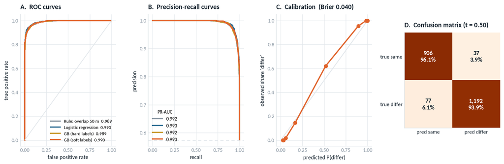

```python
fig, axes = plt.subplots(1, 4, figsize=(15.2, 4.2), gridspec_kw=dict(wspace=0.34))
ax = axes[0]
for (name, p), c in zip(preds.items(), [MUTED, BLUE, GOLD, ORANGE]):
    fpr, tpr, _ = roc_curve(y, p)
    lbl = name.replace("Gradient boosting", "GB").replace("Rule: overlap within 50 m", "Rule: overlap 50 m")
    ax.plot(fpr, tpr, color=c, lw=2.2, label=f"{lbl}  {roc_auc_score(y,p):.3f}")
ax.plot([0, 1], [0, 1], color=GRID, lw=1.2)
ax.set_xlabel("false positive rate"); ax.set_ylabel("true positive rate")
ax.legend(loc="lower right", fontsize=8.2); ax.set_title("A.  ROC curves", pad=10)

ax = axes[1]
for (name, p), c in zip(preds.items(), [MUTED, BLUE, GOLD, ORANGE]):
    pr, rc, _ = precision_recall_curve(y, p)
    ax.plot(rc, pr, color=c, lw=2.2, label=f"{average_precision_score(y,p):.3f}")
ax.axhline(y.mean(), color=GRID, lw=1.4, ls=(0, (4, 3)))
ax.set_xlabel("recall"); ax.set_ylabel("precision")
ax.legend(loc="lower left", fontsize=8.6, title="PR-AUC", title_fontsize=8.6)
ax.set_title("B.  Precision-recall curves", pad=10)

ax = axes[2]
q = pd.qcut(p_best, 10, duplicates="drop")
cal = pd.DataFrame({"p": p_best, "y": y}).groupby(q, observed=True).agg(["mean", "size"])
ax.plot([0, 1], [0, 1], color=GRID, lw=1.4)
ax.plot(cal[("p", "mean")], cal[("y", "mean")], "o-", color=ORANGE, lw=2.2, ms=6)
ax.set_xlabel("predicted P(differ)"); ax.set_ylabel("observed share 'differ'")
ax.set_title(f"C.  Calibration  (Brier {brier_score_loss(y,p_best):.3f})", pad=10)

ax = axes[3]
cm = confusion_matrix(y, yhat); cmn = cm / cm.sum(1, keepdims=True)
ax.imshow(cmn, cmap="Oranges", vmin=0, vmax=1)
for i in range(2):
    for j in range(2):
        ax.text(j, i, f"{cm[i,j]:,}\n{cmn[i,j]:.1%}", ha="center", va="center", fontsize=11,
                weight="bold", color="white" if cmn[i, j] > .55 else INK, linespacing=1.3)
ax.set_xticks([0, 1], ["pred same", "pred differ"]); ax.set_yticks([0, 1], ["true same", "true differ"])
ax.tick_params(colors=INK); ax.grid(False)
ax.set_title(f"D.  Confusion matrix (t = {T_STAR:.2f})", pad=10)
fig.savefig(f"{FIG_DIR}/D_baseline_performance.png")
plt.show()
plt.show()
```

The first thing to say is that every model here lands within about 0.002 ROC-AUC of every other one, and the one-feature rule is among them. There is not much of a ranking problem in this data: the divergences are mostly unambiguous, and a single overlap statistic finds them.

So the choice between models has to be made on something other than AUC.

**Calibration is what separates them.** The rule scores 0.140 on Brier against 0.040 for the logistic regression. That is not quite a fair comparison, since `1 - overlap` is a score rather than a probability, but it is exactly the point: a raw geometric score cannot be thresholded by cost, cannot support any kind of "not sure" output, and cannot be averaged into a statement like "estimation quality in Bogota fell four points this week". A calibrated probability does all three, and panel C shows this one tracks the diagonal closely.

**And the "I don't know" decision costs us a little on paper.** Handling it properly drops the out-of-fold AUC from 0.9908 to 0.9902. That is the right direction to expect: the model is now being asked to fit 174 genuinely ambiguous journeys that the old approach simply deleted, and it is still being graded on the easier subset where a majority exists. The slightly worse number is the more honest one, and the F1-optimal threshold landing at exactly 0.50 is a small sign that the probabilities mean more than they did.

Three models is not a search, though. Before settling on any of this I want to know whether the field is wider than it looks.

## 5. Widening the model search

There are three specific things I want to test rather than assume.

**Whether the collinearity claim holds.** The features overlap heavily by construction (five overlap thresholds, several normalised versions of the same distance). If that is true, an elastic net should be able to throw half of them away at no cost. That is a direct test of the claim rather than an assertion about it.

**Whether a different family does better.** HistGradientBoosting with hand-set parameters is one point in a large space. LightGBM and XGBoost regularise differently, a random forest has a completely different bias-variance profile from boosting, and an RBF-kernel SVM fits a smooth non-linear boundary without the axis-aligned splits that trees are stuck with.

**Whether the hand-engineered geometry is earning its place.** The entire premise of section 3 is that features built from domain reasoning beat letting a model look at the coordinates. That has never been tested here, so I add two neural nets: one on the 34 features and one on the raw polylines, resampled to 64 points each and normalised for translation, rotation and scale so the network is not being asked to learn that a trip pointing north is the same problem as a trip pointing east.

The bar for replacing the baseline is the one section 4 already set: beat it out of fold, **on both cross-validation schemes and on calibration as well as ranking**. And since comparing point estimates across ten models on 2,212 journeys will manufacture a winner whether or not one exists, every comparison against the incumbent gets a paired bootstrap over journeys on both metrics.

Two things I wanted and could not run, which are worth stating rather than quietly dropping. A proper sequence model (a 1D convolution or a GRU over the coordinate sequence) needs a deep-learning framework that is not available in this environment, and installing one to fit 2,212 rows would be hard to defend. A road-network representation, snapping both routes to OSM and comparing edge sequences, needs network access to a map server. The raw-polyline net below is a cheap proxy for the first of those, and it is a proxy, not a substitute.

```python
from sklearn.svm import SVC
from sklearn.neural_network import MLPRegressor
from sklearn.ensemble import RandomForestClassifier
import lightgbm as lgb, xgboost as xgb

# A raw-geometry representation, so "should we learn from the polylines directly?"
# gets an evidenced answer rather than an assumed one. Translation, rotation and
# scale normalised, so the label cannot depend on which way the trip happened to point.
NRAW = 64

def raw_pair(est_ll, real_ll):
    o = (np.asarray(est_ll, float)[:, 0].mean(), np.asarray(est_ll, float)[:, 1].mean())
    E, Rr = L.to_metres(est_ll, o), L.to_metres(real_ll, o)
    Es, Rs = L.resample(E, NRAW), L.resample(Rr, NRAW)
    span = Es[-1] - Es[0]
    scale = max(L.path_length(E), 1.0)
    th = np.arctan2(span[1], span[0])
    c, s = np.cos(-th), np.sin(-th)
    Rot = np.array([[c, -s], [s, c]])
    f = lambda P: ((P - Es[0]) @ Rot.T) / scale
    return np.concatenate([f(Es).ravel(), f(Rs).ravel()])

Xraw_all = pd.DataFrame([raw_pair(*routes[j]) for j in D.index], index=D.index)
Xraw = Xraw_all.loc[gold.index].to_numpy()
Xraw_x = Xraw_all.loc[extra.index].to_numpy()
print(f"raw-geometry representation: {Xraw.shape[1]} dimensions per journey")

SPLITS = {"random 5-fold": lambda: StratifiedKFold(5, shuffle=True, random_state=0).split(X, y),
          "grouped by city": lambda: GroupKFold(5).split(X, y, groups)}


def oof_predict(make, Xm, Xxm, mode="soft", splitter="random 5-fold"):
    """Out-of-fold predictions under the notebook's existing soft-label protocol."""
    out = np.zeros(len(Xm))
    for tr, te in SPLITS[splitter]():
        Xt = np.vstack([Xm[tr], Xxm])
        pt = np.r_[p_soft[tr], px]
        wt = np.r_[w_evid[tr], wx]
        if mode == "soft":
            m = soft_fit(make, Xt, pt, wt)
            out[te] = m.predict_proba(Xm[te])[:, 1]
        else:                        # regressor on the soft target (no weight support)
            m = make().fit(Xt, pt)
            out[te] = np.clip(m.predict(Xm[te]), 0, 1)
    return out


CANDIDATES = [
    ("Rule: overlap within 50 m", None, None, None, None),
    ("Logistic regression (C=1)", lambda: make_pipeline(StandardScaler(),
        LogisticRegression(max_iter=3000, C=1.0)), X, Xx, "soft"),
    ("Elastic net logistic", lambda: make_pipeline(StandardScaler(),
        LogisticRegression(max_iter=3000, penalty="elasticnet", solver="saga",
                           l1_ratio=0.5, C=1.0, tol=1e-3)), X, Xx, "soft"),
    ("HistGradientBoosting", mk_gb, X, Xx, "soft"),
    ("LightGBM", lambda: lgb.LGBMClassifier(n_estimators=300, learning_rate=0.06,
        num_leaves=15, min_child_samples=25, reg_lambda=2.0, verbose=-1,
        random_state=0), X, Xx, "soft"),
    ("XGBoost", lambda: xgb.XGBClassifier(n_estimators=300, learning_rate=0.06,
        max_depth=4, min_child_weight=5, reg_lambda=2.0, tree_method="hist",
        random_state=0, verbosity=0), X, Xx, "soft"),
    ("Random forest", lambda: RandomForestClassifier(n_estimators=400, min_samples_leaf=5,
        n_jobs=-1, random_state=0), X, Xx, "soft"),
    ("SVM, RBF kernel", lambda: make_pipeline(StandardScaler(),
        SVC(C=3.0, gamma="scale", probability=True, random_state=0)), X, Xx, "soft"),
    ("Neural net on 34 features", lambda: make_pipeline(StandardScaler(),
        MLPRegressor(hidden_layer_sizes=(64, 32), alpha=1e-3, max_iter=600,
                     early_stopping=True, random_state=0)), X, Xx, "reg"),
    ("Neural net on raw polylines", lambda: make_pipeline(StandardScaler(),
        MLPRegressor(hidden_layer_sizes=(64, 32), alpha=1e-3, max_iter=600,
                     early_stopping=True, random_state=0)), Xraw, Xraw_x, "reg"),
]

t0 = time.time()
cand_pred = {}
rows = []
for name, make, Xm, Xxm, mode in CANDIDATES:
    for sp in SPLITS:
        if make is None:
            p = 1 - gold["overlap_50m"].to_numpy()
        else:
            p = oof_predict(make, Xm, Xxm, mode=mode, splitter=sp)
        cand_pred[(name, sp)] = p
        rows.append(dict(model=name, cv=sp, roc_auc=roc_auc_score(y, p),
                         pr_auc=average_precision_score(y, p),
                         brier=brier_score_loss(y, np.clip(p, 0, 1))))
q1 = pd.DataFrame(rows)
print(f"evaluated {len(CANDIDATES)} candidates on 2 CV schemes in {time.time()-t0:.0f}s\n")
print(q1.pivot(index="model", columns="cv", values=["roc_auc", "brier"]).round(4).to_string())

INCUMBENT = "Logistic regression (C=1)"


def paired_bootstrap(pa, pb, n=800, seed=0):
    """Paired bootstrap over journeys for the difference b - a."""
    r = np.random.default_rng(seed)
    da, db = [], []
    for _ in range(n):
        i = r.integers(0, len(y), len(y))
        if len(np.unique(y[i])) < 2:
            continue
        da.append(roc_auc_score(y[i], pb[i]) - roc_auc_score(y[i], pa[i]))
        db.append(brier_score_loss(y[i], np.clip(pb[i], 0, 1))
                  - brier_score_loss(y[i], np.clip(pa[i], 0, 1)))
    return np.array(da), np.array(db)


CHALLENGERS = ["Random forest", "Elastic net logistic", "LightGBM", "XGBoost",
               "SVM, RBF kernel", "Neural net on 34 features", "Neural net on raw polylines"]
boot = {}
for name in CHALLENGERS:
    da, db = paired_bootstrap(cand_pred[(INCUMBENT, "random 5-fold")],
                              cand_pred[(name, "random 5-fold")])
    boot[name] = dict(d_auc=da.mean(), auc_lo=np.percentile(da, 2.5), auc_hi=np.percentile(da, 97.5),
                      d_brier=db.mean(), br_lo=np.percentile(db, 2.5), br_hi=np.percentile(db, 97.5))
q1_boot = pd.DataFrame(boot).T
print("\ndifference vs the incumbent, paired bootstrap, 95% interval:")
print(q1_boot.round(4).to_string())
```

```
raw-geometry representation: 256 dimensions per journey
```

```
evaluated 10 candidates on 2 CV schemes in 42s

                                    roc_auc                         brier
cv                          grouped by city random 5-fold grouped by city random 5-fold
model
Elastic net logistic                 0.9905        0.9905          0.0398        0.0398
HistGradientBoosting                 0.9895        0.9895          0.0409        0.0406
LightGBM                             0.9887        0.9893          0.0424        0.0414
Logistic regression (C=1)            0.9904        0.9902          0.0399        0.0402
Neural net on 34 features            0.9881        0.9885          0.0441        0.0433
Neural net on raw polylines          0.8163        0.8666          0.1778        0.1494
Random forest                        0.9913        0.9911          0.0402        0.0401
Rule: overlap within 50 m            0.9887        0.9887          0.1397        0.1397
SVM, RBF kernel                      0.9873        0.9872          0.0449        0.0442
XGBoost                              0.9890        0.9891          0.0421        0.0417
```

```
difference vs the incumbent, paired bootstrap, 95% interval:
                              d_auc  auc_lo  auc_hi  d_brier   br_lo   br_hi
Random forest                0.0009 -0.0003  0.0021  -0.0001 -0.0021  0.0019
Elastic net logistic         0.0003  0.0000  0.0007  -0.0004 -0.0012  0.0001
LightGBM                    -0.0009 -0.0024  0.0005   0.0011 -0.0022  0.0043
XGBoost                     -0.0011 -0.0026  0.0004   0.0015 -0.0014  0.0043
SVM, RBF kernel             -0.0030 -0.0059 -0.0004   0.0040  0.0018  0.0061
Neural net on 34 features   -0.0017 -0.0040  0.0001   0.0031  0.0009  0.0054
Neural net on raw polylines -0.1240 -0.1379 -0.1097   0.1093  0.1013  0.1169
```

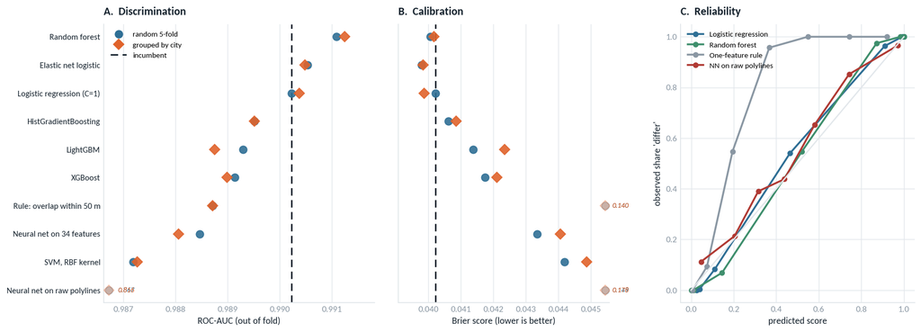

```python
fig = plt.figure(figsize=(15.6, 5.4))
gs = fig.add_gridspec(1, 4, width_ratios=[1.18, 0.92, 0.10, 1.02], wspace=0.13)
axA = fig.add_subplot(gs[0]); axB = fig.add_subplot(gs[1], sharey=axA); axC = fig.add_subplot(gs[3])
order = q1[q1.cv == "random 5-fold"].sort_values("roc_auc").model.tolist()
ypos = {m: i for i, m in enumerate(order)}
OFFSCALE = "Neural net on raw polylines"
RULE = "Rule: overlap within 50 m"
OFF = {"roc_auc": {OFFSCALE}, "brier": {OFFSCALE, RULE}}   # per metric, so the field stays readable

for ax, metric, lab in [(axA, "roc_auc", "ROC-AUC (out of fold)"),
                        (axB, "brier", "Brier score (lower is better)")]:
    dc = q1[~q1.model.isin(OFF[metric])]
    lo, hi = dc[metric].min(), dc[metric].max()
    pad = (hi - lo) * 0.14
    xlim = (lo - pad, hi + pad)
    for sp, col, mk in [("random 5-fold", BLUE, "o"), ("grouped by city", ORANGE, "D")]:
        for _, r in q1[q1.cv == sp].iterrows():
            v, yy = r[metric], ypos[r.model]
            if xlim[0] <= v <= xlim[1]:
                ax.plot(v, yy, mk, color=col, ms=8, alpha=.9, zorder=3)
            else:                                   # off the scale, shown at the edge
                edge = xlim[0] + pad * .18 if v < xlim[0] else xlim[1] - pad * .18
                ax.plot(edge, yy, mk, color=col, ms=8, alpha=.30, zorder=3)
                ax.text(edge + pad * .30, yy, f"{v:.3f}", fontsize=7.8, color=col,
                        va="center", style="italic")
    inc = q1[(q1.model == INCUMBENT) & (q1.cv == "random 5-fold")][metric].iloc[0]
    ax.axvline(inc, color=INK, lw=1.6, ls=(0, (5, 3)), zorder=2)
    ax.set_xlim(*xlim); ax.set_xlabel(lab)
    ax.grid(axis="y", visible=False)
axA.set_yticks(range(len(order)), order, fontsize=9)
axA.tick_params(axis="y", labelcolor=INK)
plt.setp(axB.get_yticklabels(), visible=False)
axA.legend(handles=[plt.Line2D([], [], marker="o", color=BLUE, ls="", ms=8, label="random 5-fold"),
                    plt.Line2D([], [], marker="D", color=ORANGE, ls="", ms=8, label="grouped by city"),
                    plt.Line2D([], [], color=INK, ls=(0, (5, 3)), lw=1.6, label="incumbent")],
           loc="upper left", fontsize=8.4, framealpha=.95)
axA.set_title("A.  Discrimination", pad=10)
axB.set_title("B.  Calibration", pad=10)

for name, col, lab in [(INCUMBENT, BLUE, "Logistic regression"),
                       ("Random forest", GREEN, "Random forest"),
                       ("Rule: overlap within 50 m", MUTED, "One-feature rule"),
                       (OFFSCALE, RED, "NN on raw polylines")]:
    p = cand_pred[(name, "random 5-fold")]
    q = pd.qcut(p, 8, duplicates="drop")
    c = pd.DataFrame({"p": p, "y": y}).groupby(q, observed=True).mean()
    axC.plot(c.p, c.y, "o-", color=col, lw=2.0, ms=5, label=lab)
axC.plot([0, 1], [0, 1], color=GRID, lw=1.4)
axC.set_xlabel("predicted score"); axC.set_ylabel("observed share 'differ'")
axC.legend(loc="upper left", fontsize=8.4)
axC.set_title("C.  Reliability", pad=10)
fig.savefig(f"{FIG_DIR}/G_model_search.png")
plt.show()
plt.show()
```

Read the intervals, not the ranking.

**Random forest** has the best point estimate on ROC-AUC, +0.0009 above the incumbent, and its interval is [-0.0003, +0.0021]. It contains zero. Its Brier difference is -0.0001 with an interval of [-0.0021, +0.0019], which contains zero twice over. On the evidence available, the forest and the logistic regression are the same model wearing different clothes, and one of them is 400 trees.

**The boosters and the kernel method** do not help. LightGBM and XGBoost come in slightly below the incumbent on both metrics, and the SVM is worse on both by a margin that does clear zero.

It is worth putting these numbers in units that mean something. The gap between the incumbent and a perfect classifier on this evaluation set is 0.0098 ROC-AUC. The best challenger closes 0.0003 of it, about three per cent of the remaining headroom, on labels where the same annotator contradicts themselves 11.5% of the time. Relabel 122 journeys and that entire difference moves around underneath us.

The result I do think is real is the **neural net on raw polylines at 0.867 ROC-AUC against 0.990**, with a Brier three times worse, and it holds under both splits. The honest reading is not "neural networks are bad". It is that the 34 features encode things the network cannot recover from 128 normalised coordinates at this sample size. The sustained-detour statistics in particular are the kind of feature that takes a great many examples to learn and almost no thought to write down. That is a statement about n equals 2,212, not about the approach, and with an order of magnitude more labels, or with road-network edges instead of bare coordinates, I would expect the ordering to change.

So the wider search does not change the model. It does tell us the baseline was not a lucky guess.

## 6. Hyperparameter optimisation

The obvious next question is whether the incumbent is being held back by its defaults. I am skeptical here for three reasons, and the way to settle it is to run the search rather than argue about it.

**Sample size.** 2,212 scoreable journeys and 34 correlated features, with a five-fold split, means each fold-level estimate rests on about 440 journeys. A grid search has enough freedom at that N to pick up fold noise and call it signal.

**Headroom.** Whatever tuning can win is bounded by the distance to a ceiling that we are already close to.

**The objective.** This one decides the protocol. ROC-AUC is invariant to any monotone transformation of the score, so a search optimising it is indifferent to calibration, and calibration is the entire reason section 4 chose this model. The search has to score Brier.

On method: if we tune, it has to be nested. The grid gets chosen inside each outer fold and the outer fold is scored once, on parameters it never saw. Tuning on the same five folds we report is not a smaller sin than tuning on the test set, it is the same sin with more steps. I run a bounded grid on C and the penalty type for the linear model, and a small grid on the two parameters that actually matter for a booster, keeping LightGBM in for comparison since it was the closest of the tree models.

```python
def nested_cv(build, grid, Xm, Xxm, mode="soft", score="brier", inner=3):
    """Outer folds give an honest score; the grid is chosen inside each fold only."""
    oof = np.zeros(len(Xm)); chosen = []
    for tr, te in StratifiedKFold(5, shuffle=True, random_state=0).split(Xm, y):
        best, best_s = None, np.inf
        for g in grid:
            ss = []
            for i_tr, i_te in StratifiedKFold(inner, shuffle=True, random_state=1).split(Xm[tr], y[tr]):
                a, b = tr[i_tr], tr[i_te]
                Xt = np.vstack([Xm[a], Xxm]); pt = np.r_[p_soft[a], px]; wt = np.r_[w_evid[a], wx]
                m = soft_fit(lambda: build(g), Xt, pt, wt) if mode == "soft" else build(g).fit(Xt, pt)
                pv = m.predict_proba(Xm[b])[:, 1] if mode == "soft" else np.clip(m.predict(Xm[b]), 0, 1)
                ss.append(brier_score_loss(y[b], pv) if score == "brier"
                          else -roc_auc_score(y[b], pv))
            if np.mean(ss) < best_s:
                best, best_s = g, np.mean(ss)
        chosen.append(best)
        Xt = np.vstack([Xm[tr], Xxm]); pt = np.r_[p_soft[tr], px]; wt = np.r_[w_evid[tr], wx]
        m = soft_fit(lambda: build(best), Xt, pt, wt)
        oof[te] = m.predict_proba(Xm[te])[:, 1]
    return oof, chosen


lr_grid = [dict(C=c, penalty=p) for c in (0.03, 0.1, 0.3, 1, 3, 10) for p in ("l2", "l1")]
build_lr = lambda g: make_pipeline(StandardScaler(), LogisticRegression(
    max_iter=1500, tol=1e-3, C=g["C"], penalty=g["penalty"], solver="saga" if g["penalty"] == "l1" else "lbfgs"))
t0 = time.time()
p_lr_tuned, chosen_lr = nested_cv(build_lr, lr_grid, X, Xx)
print(f"nested CV for logistic regression in {time.time()-t0:.0f}s")
print("  C chosen per outer fold:", [f"{g['C']}/{g['penalty']}" for g in chosen_lr])

gb_grid = [dict(num_leaves=n, learning_rate=lr) for n in (7, 15, 31) for lr in (0.03, 0.06)]
build_gb = lambda g: lgb.LGBMClassifier(n_estimators=300, num_leaves=g["num_leaves"],
    learning_rate=g["learning_rate"], min_child_samples=25, reg_lambda=2.0,
    verbose=-1, random_state=0)
p_gb_tuned, chosen_gb = nested_cv(build_gb, gb_grid, X, Xx)
print("  LightGBM chosen per outer fold:", [f"{g['num_leaves']}/{g['learning_rate']}" for g in chosen_gb])

p_inc = cand_pred[(INCUMBENT, "random 5-fold")]
q2 = pd.DataFrame([
    dict(model="Logistic regression, default C=1", roc_auc=roc_auc_score(y, p_inc),
         brier=brier_score_loss(y, p_inc)),
    dict(model="Logistic regression, nested-CV tuned", roc_auc=roc_auc_score(y, p_lr_tuned),
         brier=brier_score_loss(y, p_lr_tuned)),
    dict(model="LightGBM, default", roc_auc=q1[(q1.model == "LightGBM") & (q1.cv == "random 5-fold")].roc_auc.iloc[0],
         brier=q1[(q1.model == "LightGBM") & (q1.cv == "random 5-fold")].brier.iloc[0]),
    dict(model="LightGBM, nested-CV tuned", roc_auc=roc_auc_score(y, p_gb_tuned),
         brier=brier_score_loss(y, p_gb_tuned)),
]).set_index("model")
print("\n" + q2.round(4).to_string())
d_auc_t, d_br_t = paired_bootstrap(p_inc, p_lr_tuned)
print(f"\ntuning gain over default, 95% interval: "
      f"ROC-AUC {d_auc_t.mean():+.4f} [{np.percentile(d_auc_t,2.5):+.4f}, {np.percentile(d_auc_t,97.5):+.4f}] | "
      f"Brier {d_br_t.mean():+.4f} [{np.percentile(d_br_t,2.5):+.4f}, {np.percentile(d_br_t,97.5):+.4f}]")

d_auc_g, d_br_g = paired_bootstrap(p_inc, p_gb_tuned)
print(f"tuned LightGBM vs default LR, 95% interval: "
      f"ROC-AUC {d_auc_g.mean():+.4f} [{np.percentile(d_auc_g,2.5):+.4f}, {np.percentile(d_auc_g,97.5):+.4f}] | "
      f"Brier {d_br_g.mean():+.4f} [{np.percentile(d_br_g,2.5):+.4f}, {np.percentile(d_br_g,97.5):+.4f}]")

# inner-loop shape: how flat is the objective in C?
curve = []
for g in [dict(C=c, penalty="l2") for c in (0.03, 0.1, 0.3, 1, 3, 10)]:
    ss = []
    for tr, te in StratifiedKFold(3, shuffle=True, random_state=2).split(X, y):
        Xt = np.vstack([X[tr], Xx]); pt = np.r_[p_soft[tr], px]; wt = np.r_[w_evid[tr], wx]
        m = soft_fit(lambda: build_lr(g), Xt, pt, wt)
        ss.append(brier_score_loss(y[te], m.predict_proba(X[te])[:, 1]))
    curve.append(dict(C=g["C"], brier=np.mean(ss), sd=np.std(ss)))
curve = pd.DataFrame(curve)
print("\n" + curve.round(4).to_string(index=False))
```

```
nested CV for logistic regression in 13s
  C chosen per outer fold: ['1/l1', '1/l1', '3/l1', '1/l1', '3/l2']
```

```
  LightGBM chosen per outer fold: ['31/0.03', '7/0.03', '7/0.03', '15/0.03', '7/0.03']

                                      roc_auc   brier
model
Logistic regression, default C=1       0.9902  0.0402
Logistic regression, nested-CV tuned   0.9897  0.0403
LightGBM, default                      0.9893  0.0414
LightGBM, nested-CV tuned              0.9903  0.0395
```

```
tuning gain over default, 95% interval: ROC-AUC -0.0005 [-0.0019, +0.0002] | Brier +0.0000 [-0.0004, +0.0005]
```

```
tuned LightGBM vs default LR, 95% interval: ROC-AUC +0.0001 [-0.0011, +0.0014] | Brier -0.0007 [-0.0033, +0.0018]

    C  brier     sd
 0.03 0.0429 0.0022
 0.10 0.0411 0.0023
 0.30 0.0404 0.0023
 1.00 0.0406 0.0029
 3.00 0.0406 0.0029
10.00 0.0406 0.0029
```

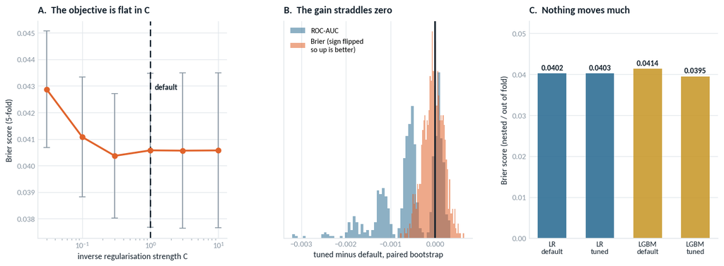

```python
fig, axes = plt.subplots(1, 3, figsize=(14.6, 4.7), gridspec_kw=dict(wspace=0.30))
ax = axes[0]
ax.errorbar(curve.C, curve.brier, yerr=curve.sd, fmt="o-", color=ORANGE, lw=2.2, ms=6,
            capsize=4, ecolor=MUTED, elinewidth=1.2)
ax.axvline(1.0, color=INK, lw=1.6, ls=(0, (5, 3)))
ax.text(1.15, curve.brier.max(), "default", fontsize=9.2, color=INK, weight="bold")
ax.set_xscale("log"); ax.set_xlabel("inverse regularisation strength C")
ax.set_ylabel("Brier score (5-fold)")
ax.set_title("A.  The objective is flat in C", pad=10)

ax = axes[1]
for i, (d, lab, col) in enumerate([(d_auc_t, "ROC-AUC", BLUE), (d_br_t * -1, "Brier (sign flipped\nso up is better)", ORANGE)]):
    ax.hist(d, bins=60, color=col, alpha=.55, density=True, label=lab)
ax.axvline(0, color=INK, lw=2.0)
ax.set_xlabel("tuned minus default, paired bootstrap")
ax.set_yticks([]); ax.legend(fontsize=8.8, loc="upper left")
ax.set_title("B.  The gain straddles zero", pad=10)

ax = axes[2]
lbl = ["LR\ndefault", "LR\ntuned", "LGBM\ndefault", "LGBM\ntuned"]
ax.bar(range(4), q2.brier.values, color=[BLUE, BLUE, GOLD, GOLD], width=.6,
       alpha=.9)
for i, v in enumerate(q2.brier.values):
    ax.text(i, v + .0008, f"{v:.4f}", ha="center", fontsize=9.4, weight="bold", color=INK)
ax.set_xticks(range(4), lbl, fontsize=9)
ax.tick_params(axis="x", labelcolor=INK)
ax.set_ylabel("Brier score (nested / out of fold)")
ax.set_ylim(0, max(q2.brier) * 1.28)
ax.grid(axis="x", visible=False)
ax.set_title("C.  Nothing moves much", pad=10)
fig.savefig(f"{FIG_DIR}/H_hyperparameter_tuning.png")
plt.show()
plt.show()
```

Panel A is the answer and the rest is commentary. From C equal to 0.3 up to 10, the Brier score moves by 0.0002, while the fold-to-fold standard deviation at each of those points is between 0.0023 and 0.0029. The spread we would be optimising is an order of magnitude smaller than the noise in our own measurement of it. There is no peak to find.

The nested result confirms it from the other direction. Tuned logistic regression comes out at 0.9897 ROC-AUC against 0.9902 for the default, which is to say tuning made it slightly **worse** out of fold, with a bootstrap interval straddling zero and Brier unchanged to four decimals. Tuning coming out worse is the diagnostic signature of a search fitting inner-fold noise, and it is the strongest single piece of evidence that the flat region in panel A is real rather than an artefact of a coarse grid. The chosen parameter is not stable either: three folds picked C of 1 with an L1 penalty, one picked 3 with L1, one picked 3 with L2. A search whose answer changes with the fold is describing the fold, not the problem.

The line worth flagging is tuned LightGBM, which lands at 0.9903 ROC-AUC and 0.0395 Brier, marginally the best numbers on the page. That is exactly the result that looks like a win and then regresses in production. Look at what it selected: 31 leaves in one fold, 7 in three others, 15 in the last. That is not an optimum, and its bootstrap interval against the incumbent still contains zero.

**Where that leaves the model.** Ten alternatives and a nested search over two of them produced nothing that beats a default logistic regression on the evidence available, so that is what I keep: `StandardScaler` plus `LogisticRegression(C=1.0, penalty="l2")`, trained on the soft target with evidence weights. Two caveats attached to that decision. The flat regularisation surface is a property of this sample size, so if the labelling depth grows substantially this is worth revisiting. And "we checked and it does not help" is a different claim from "we never checked", which is why the nested cross-validation stays in the notebook rather than being deleted now that it came out negative.

## 7. Performance assessment and generalisation

Now that the model is settled, an AUC of 0.99 still does not answer either of the two questions that would decide whether to put it into production.

The first is what we are comparing against. A model trained to reproduce human judgements cannot sensibly be measured against perfection, because the humans are not perfect either. We have two better yardsticks: the self-consistency figure from section 1, and the rate at which two different annotators agree with each other on the journeys that were seen twice.

The second is whether the thing generalises. The sample spans 28 cities in 7 countries, with very different street grids and trip lengths, so we can hold out an entire city at a time and see what happens.

```python
# does it survive being moved to a city it has never seen?
p_geo = cv_predict(mk_lr, soft=True, splitter=GroupKFold(5).split(X, y, groups))
GEO_AUC = roc_auc_score(y, p_geo)
print(f"grouped-by-city CV ROC-AUC: {GEO_AUC:.4f}  (random CV {roc_auc_score(y,p_best):.4f})")

top_cities = gold.city.value_counts()
top_cities = top_cities[top_cities >= 40].index.tolist()
city_rows = []
for c in top_cities:
    te = groups == c
    m = fit_w(mk_lr(), np.vstack([X[~te], X[~te]]),
              np.r_[np.ones((~te).sum()), np.zeros((~te).sum())],
              np.r_[p_soft[~te], 1 - p_soft[~te]])
    pc = m.predict_proba(X[te])[:, 1]
    city_rows.append(dict(city=c, n=int(te.sum()), differ=float(y[te].mean()),
                          auc=roc_auc_score(y[te], pc) if len(set(y[te])) > 1 else np.nan))
city_perf = pd.DataFrame(city_rows).sort_values("n", ascending=False)
print(city_perf.round(3).to_string(index=False))
```

```
grouped-by-city CV ROC-AUC: 0.9904  (random CV 0.9902)
        city   n  differ   auc
Buenos Aires 587   0.554 0.994
      Bogotá 482   0.610 0.986
    Santiago 267   0.610 0.992
      Madrid 245   0.539 0.986
        Lima 231   0.589 0.987
   Barcelona  72   0.569 0.993
    Medellín  47   0.617 0.996
       Quito  43   0.558 0.982
Córdoba (AR)  42   0.738 0.982
```

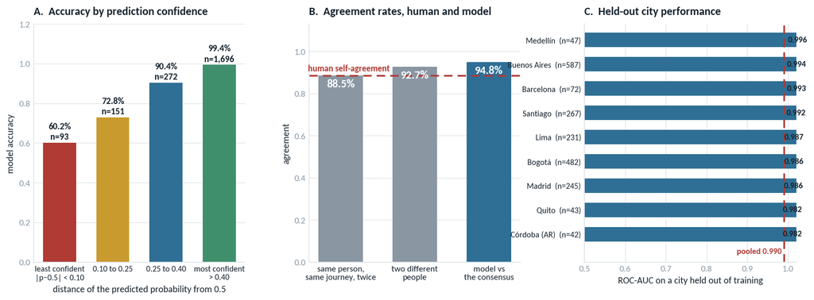

```python
fig, axes = plt.subplots(1, 3, figsize=(14.6, 4.6), gridspec_kw=dict(wspace=0.30))
ax = axes[0]
conf = np.abs(p_best - 0.5)
band = pd.cut(conf, [-.001, .10, .25, .40, .501],
              labels=["least confident\n|p−0.5| < 0.10", "0.10 to 0.25", "0.25 to 0.40",
                      "most confident\n> 0.40"])
acc = pd.DataFrame({"b": band, "ok": (yhat == y)}).groupby("b", observed=True)["ok"] \
        .agg(["mean", "size"])
ax.bar(range(len(acc)), acc["mean"], color=[RED, GOLD, BLUE, GREEN][:len(acc)], width=.62)
for i, (m_, n_) in enumerate(zip(acc["mean"], acc["size"])):
    ax.text(i, m_ + .018, f"{m_:.1%}\nn={int(n_):,}", ha="center", fontsize=9.6, weight="bold",
            color=INK, linespacing=1.3)
ax.set_xticks(range(len(acc)), acc.index, fontsize=8.8)
ax.tick_params(axis="x", labelcolor=INK)
ax.set_ylim(0, 1.20); ax.set_ylabel("model accuracy")
ax.set_xlabel("distance of the predicted probability from 0.5")
ax.grid(axis="x", visible=False)
ax.set_title("A.  Accuracy by prediction confidence", pad=10)

ax = axes[1]
bars = {"same person,\nsame journey, twice": SELF_CONSISTENCY,
        "two different\npeople": PAIR_AGREE,
        "model vs\nthe consensus": accuracy_score(y, yhat)}
ax.bar(range(3), list(bars.values()), color=[MUTED, MUTED, BLUE], width=.6)
for i, v in enumerate(bars.values()):
    ax.text(i, v - .055, f"{v:.1%}", ha="center", fontsize=12, weight="bold", color="white")
ax.axhline(SELF_CONSISTENCY, color=RED, lw=1.8, ls=(0, (5, 3)))
ax.text(-.44, SELF_CONSISTENCY + .022, "human self-agreement", ha="left", fontsize=9.2,
        color=RED, weight="bold")
ax.set_xticks(range(3), list(bars), fontsize=9.2)
ax.tick_params(axis="x", labelcolor=INK)
ax.set_ylim(0, 1.13); ax.set_ylabel("agreement")
ax.grid(axis="x", visible=False)
ax.set_title("B.  Agreement rates, human and model", pad=10)

ax = axes[2]
cp = city_perf.dropna(subset=["auc"]).sort_values("auc")
ax.barh(range(len(cp)), cp.auc, color=BLUE, height=.6, left=.5)
for i, (_, r) in enumerate(cp.iterrows()):
    ax.text(r.auc + .004, i, f"{r.auc:.3f}", va="center", fontsize=9, color=INK, weight="bold")
ax.axvline(GEO_AUC, color=RED, lw=1.8, ls=(0, (5, 3)))
ax.text(GEO_AUC - .006, -0.72, f"pooled {GEO_AUC:.3f}", ha="right", va="center",
        fontsize=8.8, color=RED, weight="bold")
ax.set_ylim(-1.15, len(cp) - .35)
ax.set_yticks(range(len(cp)), [f"{r.city}  (n={r.n})" for _, r in cp.iterrows()], fontsize=8.8)
ax.tick_params(axis="y", labelcolor=INK)
ax.set_xlim(.5, 1.02); ax.set_xlabel("ROC-AUC on a city held out of training")
ax.grid(axis="y", visible=False)
ax.set_title("C.  Held-out city performance", pad=10)
fig.savefig(f"{FIG_DIR}/E_ceiling_and_transfer.png")
plt.show()
plt.show()
```

**Panel A** turns out to be the most useful chart in the notebook. Accuracy is 99.4% on the 1,696 journeys where the model is confident (predicted probability more than 0.40 away from 0.5) and falls to 60.2% on the 93 where it is not. The errors are not scattered: they concentrate in a band that the model identifies by itself, before anyone looks at a label. Adding up across the three lower bands, the least confident 23% of journeys contain roughly 90% of all the errors.

**Panel B** puts the headline number in context:

| Comparison | Agreement |
| --- | --- |
| Same annotator, same journey, shown twice | 88.5% |
| Two different annotators, same journey | 92.7% (kappa 0.850) |
| Model against the consensus | 94.8% |

The model agrees with the panel more often than the panel agrees with itself. The caveat is real and worth stating: it was trained on that consensus, so it is optimised for exactly the target it is being graded against, while each person is being judged against a consensus they only partly shaped. I would not claim the model is better than the annotators. I would claim it is about as reliable as one of them, which is all that matters for a system meant to replace bulk manual review.

## 8. Model interpretation and error analysis

Two questions before deciding how to use this: what is the model actually using, and what do its mistakes look like.

```
largest permutation importance: 0.0149 | overlap_25m
```

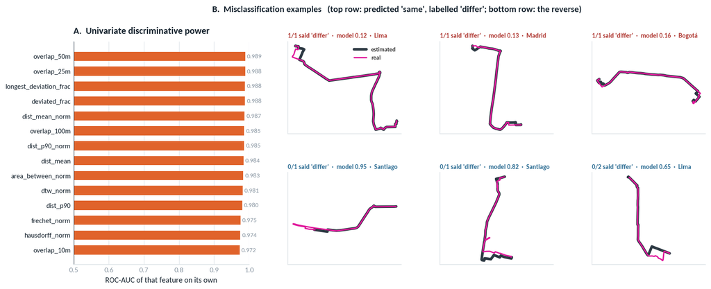

```
figures written
```

```python
m_full = mk_lr().fit(X, y)
pi = permutation_importance(m_full, X, y, n_repeats=8, random_state=0, scoring="roc_auc")
perm = pd.Series(pi.importances_mean, index=FEATS).sort_values(ascending=False)
print("largest permutation importance:", f"{perm.iloc[0]:.4f}", "|", perm.index[0])
uni_auc = pd.Series({c: max(a := roc_auc_score(y, gold[c].to_numpy()), 1 - a) for c in FEATS})
top = uni_auc.sort_values()[-14:]

fig = plt.figure(figsize=(14.6, 5.2))
gs = fig.add_gridspec(2, 4, width_ratios=[1.55, 1, 1, 1], wspace=.30, hspace=.42)
ax = fig.add_subplot(gs[:, 0])
ax.barh(range(len(top)), top.values - .5, color=ORANGE, height=.62, left=.5)
for i, v in enumerate(top.values):
    ax.text(v + .005, i, f"{v:.3f}", va="center", fontsize=8.4, color=MUTED)
ax.axvline(.5, color=INK, lw=1.4)
ax.set_yticks(range(len(top)), top.index, fontsize=9)
ax.tick_params(axis="y", labelcolor=INK)
ax.set_xlim(.5, 1.0); ax.set_xlabel("ROC-AUC of that feature on its own")
ax.grid(axis="y", visible=False)
ax.set_title("A.  Univariate discriminative power", pad=10)

_e = gold.assign(p=p_best, yhat=yhat)
_m = _e[_e.n_ann >= 2]
fn = _m.query("majority == 1 and yhat == 0").nsmallest(3, "p")
fp = _m.query("majority == 0 and yhat == 1").nlargest(3, "p")
if len(fn) < 3: fn = _e.query("majority == 1 and yhat == 0").nsmallest(3, "p")
if len(fp) < 3: fp = _e.query("majority == 0 and yhat == 1").nlargest(3, "p")
for k, (jid, row) in enumerate(pd.concat([fn, fp]).iterrows()):
    axk = fig.add_subplot(gs[k // 3, 1 + k % 3])
    e, r = np.array(routes[jid][0]), np.array(routes[jid][1])
    axk.plot(e[:, 1], e[:, 0], color=INK, lw=3.4, alpha=.9, solid_capstyle="round",
             label="estimated", zorder=2)
    axk.plot(r[:, 1], r[:, 0], color="#e0179b", lw=1.7, solid_capstyle="round",
             label="real", zorder=3)
    axk.set_xticks([]); axk.set_yticks([]); axk.grid(False)
    axk.set_aspect("equal", adjustable="datalim")
    nd, tot = int(row.n_diff), int(row.n_diff + row.n_same)
    axk.set_title(f"{nd}/{tot} said 'differ'  ·  model {row.p:.2f}  ·  {row.city}",
                  fontsize=8.4, color=RED if k < 3 else BLUE, pad=5)
    if k == 0:
        axk.legend(fontsize=7.8, loc="best", framealpha=.9)
fig.text(0.295, 1.005, "B.  Misclassification examples   (top row: predicted 'same', labelled "
         "'differ'; bottom row: the reverse)",
         fontsize=11.4, weight="bold", color=INK, ha="left", va="top")
fig.savefig(f"{FIG_DIR}/F_importance_and_errors.png")
plt.show()
plt.show()

scores.to_csv("/home/claude/p2_scores.csv")
city_perf.to_csv("/home/claude/p2_city.csv", index=False)
print("\nfigures written")
```

Permutation importance peaks at 0.015 ROC-AUC, which is small for every single feature. That is not because the features are useless, it is because they are heavily collinear: shuffle one and the model reconstructs the same information from its neighbours. This is the same property the elastic net demonstrated from the other direction in section 5, where dropping features outright cost three ten-thousandths of a point. Reporting permutation importance as-is would be misleading, so panel A shows each feature's standalone ROC-AUC instead. The overlap family leads (overlap within 50 m at 0.989, within 25 m at 0.988), with the sustained-detour features close behind, which matches the reasoning that motivated them.

The errors are more interesting than the importances. Both failure modes look like label noise rather than model error:

- Routes that overlap almost exactly, which a single annotator nonetheless called different. All three examples are journeys with one vote and no second opinion.
- Routes with a clearly visible divergence that somebody waved through as the same.

Neither is fixable with better features, and the model's probabilities on these cases are confident and wrong in precisely the way a second annotator would have been confident and right. That points at more annotation rather than more modelling.

## 9. Setting the decision threshold

There is a problem in the confusion matrix from section 4 that the modelling work has not touched. At the F1-optimal cut, 78 journeys that annotators said had diverged were predicted as matching, which is 6.1% of the true divergences. Needless flags run at 37, or 3.9%. The model is roughly one and a half times more likely to make the expensive mistake than the cheap one, and the two are not remotely equivalent: a needless flag costs an analyst two minutes, while a missed divergence is a fare calculated on a route nobody drove, charged to a customer, and found later by them rather than by us.

It is worth being precise about what this is, because the framing matters. **This is not a bias in the model.** It is the arithmetic of putting a 0.50 cut on a calibrated probability in a problem where the two errors do not cost the same. F1 weights precision and recall equally, which is a statement about the metric, not about the business. Nothing needs retraining. What needs to happen is that the threshold gets derived from costs, which is a step I skipped when I took the F1 optimum as a convenient default in section 4.

There is a closed form, so no search is needed. If the score is calibrated, and a missed divergence costs A while a needless flag costs B, then the expected cost of predicting "same" at probability p is pA and of predicting "differ" is (1-p)B. Setting those equal gives a cut at B/(A+B). Note the precondition: this works only because the probability is calibrated, which is why the Brier bar in sections 4 and 5 was not pedantry.

For the costs themselves I need numbers from pricing rather than from the data, so what follows is an assumption to be signed off and not a measurement. A needless flag is one analyst review, so call it one unit. A missed divergence is the fare correction, the support contact and the goodwill, and I would put it at around twelve units, with anything from three to twenty-five arguable. A precautionary review, where the journey goes to a person before anything reaches a customer, is cheaper than a flag because nothing has gone wrong yet: call it about half a unit. The sensitivity is shown rather than a single number asserted.

```python
p_final = p_inc                      # the model retained above
cm_050 = confusion_matrix(y, (p_final >= 0.50).astype(int))
print("at the 0.50 threshold:")
print(f"  false 'same'  (missed divergence): {cm_050[1,0]:4d}  = {cm_050[1,0]/cm_050[1].sum():.1%} of true 'differ'")
print(f"  false 'differ' (needless review) : {cm_050[0,1]:4d}  = {cm_050[0,1]/cm_050[0].sum():.1%} of true 'same'")

# cost model: A = a missed divergence, B = a needless flag, R = a human review
def three_way(p, A, B, R):
    t_lo = min(R / A, B / (A + B))
    t_hi = max(1 - R / B, B / (A + B))
    accept, flag = p < t_lo, p > t_hi
    review = ~(accept | flag)
    cost = (A * y[accept].sum() + B * (1 - y[flag]).sum() + R * review.sum())
    return dict(t_lo=t_lo, t_hi=t_hi, review=review.mean(), cost=cost / len(p),
                fn=int(y[accept].sum()), fp=int((1 - y[flag]).sum()))

grid_rows = []
for A in (3, 6, 12, 25):
    for R in (0.2, 0.4, 0.8):
        r = three_way(p_final, A, 1.0, R); r.update(A=A, R=R); grid_rows.append(r)
q3 = pd.DataFrame(grid_rows)
print("\nthree-way operating points (B = 1 needless flag):")
print(q3[["A", "R", "t_lo", "t_hi", "review", "fn", "fp", "cost"]].round(3).to_string(index=False))

A_STAR, B_STAR, R_STAR = 12.0, 1.0, 0.4
T_COST = B_STAR / (A_STAR + B_STAR)          # two-way cost-optimal cut
yhat_cost = (p_final >= T_COST).astype(int)
cm_cost = confusion_matrix(y, yhat_cost)
band = three_way(p_final, A_STAR, B_STAR, R_STAR)
print(f"\ncost-optimal two-way threshold for A/B = {A_STAR:.0f}: t = {T_COST:.3f}")
print(f"  false 'same' {cm_cost[1,0]} ({cm_cost[1,0]/cm_cost[1].sum():.1%})  "
      f"false 'differ' {cm_cost[0,1]} ({cm_cost[0,1]/cm_cost[0].sum():.1%})")
print(f"three-way: accept below {band['t_lo']:.3f}, flag above {band['t_hi']:.3f}, "
      f"review {band['review']:.1%} of volume; residual FN {band['fn']}, FP {band['fp']}")

CAP = 0.25                                  # review capacity, share of volume
scan = [(R, three_way(p_final, A_STAR, B_STAR, R)) for R in np.linspace(0.2, 1.2, 101)]
feasible = [(R, d) for R, d in scan if d["review"] <= CAP]
R_CAP, band_cap = feasible[0]
print(f"\ncapacity-constrained point (review <= {CAP:.0%}): R = {R_CAP:.2f} -> "
      f"accept below {band_cap['t_lo']:.3f}, flag above {band_cap['t_hi']:.3f}, "
      f"review {band_cap['review']:.1%}, residual FN {band_cap['fn']}, FP {band_cap['fp']}")

# does asymmetric training weighting achieve anything a threshold move does not?
def cost_weighted(scale):
    out = np.zeros(len(X))
    for tr, te in SPLITS["random 5-fold"]():
        Xt = np.vstack([X[tr], Xx]); pt = np.r_[p_soft[tr], px]; wt = np.r_[w_evid[tr], wx]
        Xa = np.vstack([Xt, Xt])
        ya = np.r_[np.ones(len(Xt)), np.zeros(len(Xt))]
        wa = np.r_[pt * wt * scale, (1 - pt) * wt]
        k = wa > 1e-9
        m = fit_w(make_pipeline(StandardScaler(), LogisticRegression(max_iter=3000)),
                  Xa[k], ya[k], wa[k])
        out[te] = m.predict_proba(X[te])[:, 1]
    return out

p_cw = cost_weighted(A_STAR)
cm_cw = confusion_matrix(y, (p_cw >= 0.50).astype(int))
print(f"\ncost-weighted training (positive class x{A_STAR:.0f}), judged at 0.50:")
print(f"  ROC-AUC {roc_auc_score(y, p_cw):.4f} (vs {roc_auc_score(y, p_final):.4f}) | "
      f"Brier {brier_score_loss(y, p_cw):.4f} (vs {brier_score_loss(y, p_final):.4f})")
print(f"  false 'same' {cm_cw[1,0]}  false 'differ' {cm_cw[0,1]}")
```

```
at the 0.50 threshold:
  false 'same'  (missed divergence):   78  = 6.1% of true 'differ'
  false 'differ' (needless review) :   37  = 3.9% of true 'same'

three-way operating points (B = 1 needless flag):
 A   R  t_lo  t_hi  review  fn  fp  cost
 3 0.2 0.067  0.80   0.238   2   7 0.054
 3 0.4 0.133  0.60   0.129   8  19 0.071
 3 0.8 0.250  0.25   0.000  26 113 0.086
 6 0.2 0.033  0.80   0.351   0   7 0.073
 6 0.4 0.067  0.60   0.195   2  19 0.092
 6 0.8 0.133  0.20   0.032   8 145 0.113
12 0.2 0.017  0.80   0.500   0   7 0.103
12 0.4 0.033  0.60   0.308   0  19 0.132
12 0.8 0.067  0.20   0.099   2 145 0.155
25 0.2 0.008  0.80   0.509   0   7 0.105
25 0.4 0.016  0.60   0.458   0  19 0.192
25 0.8 0.032  0.20   0.227   0 145 0.247

cost-optimal two-way threshold for A/B = 12: t = 0.077
  false 'same' 3 (0.2%)  false 'differ' 318 (33.7%)
three-way: accept below 0.033, flag above 0.600, review 30.8% of volume; residual FN 0, FP 19

capacity-constrained point (review <= 25%): R = 0.49 -> accept below 0.041, flag above 0.510, review 24.5%, residual FN 0, FP 35

cost-weighted training (positive class x12), judged at 0.50:
  ROC-AUC 0.9893 (vs 0.9902) | Brier 0.0876 (vs 0.0402)
  false 'same' 7  false 'differ' 256
```

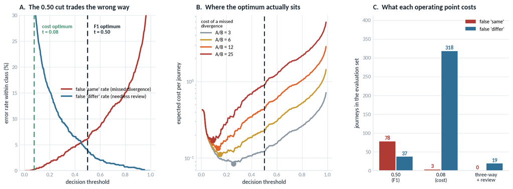

```
retained operating point: accept < 0.041, review, flag > 0.510
  automated share 75.5% of volume, 35 errors in it = 97.9% accuracy
  missed divergences inside the automated share: 0 (was 78 at the 0.50 cut)

committee figures written
```

```python
fig, axes = plt.subplots(1, 3, figsize=(15.0, 4.8), gridspec_kw=dict(wspace=0.30))
ts = np.linspace(0.01, 0.99, 300)
fn_r = [( (p_final < t) & (y == 1)).sum() / (y == 1).sum() for t in ts]
fp_r = [( (p_final >= t) & (y == 0)).sum() / (y == 0).sum() for t in ts]
ax = axes[0]
ax.plot(ts, np.array(fn_r) * 100, color=RED, lw=2.4, label="false 'same' rate (missed divergence)")
ax.plot(ts, np.array(fp_r) * 100, color=BLUE, lw=2.4, label="false 'differ' rate (needless review)")
for t, c, lab, tx in [(0.50, INK, "F1 optimum", 0.55), (T_COST, GREEN, "cost optimum", 0.14)]:
    ax.axvline(t, color=c, lw=1.8, ls=(0, (5, 3)))
    ax.text(tx, 28.2, f"{lab}\nt = {t:.2f}", fontsize=9, color=c, weight="bold",
            va="top", linespacing=1.3)
ax.set_xlabel("decision threshold"); ax.set_ylabel("error rate within class (%)")
ax.set_ylim(0, 30); ax.legend(fontsize=8.6, loc="center right")
ax.set_title("A.  The 0.50 cut trades the wrong way", pad=10)

ax = axes[1]
for A, col in [(3, MUTED), (6, GOLD), (12, ORANGE), (25, RED)]:
    cost = [(A * ((p_final < t) & (y == 1)).sum() + ((p_final >= t) & (y == 0)).sum()) / len(y)
            for t in ts]
    ax.plot(ts, cost, color=col, lw=2.2, label=f"A/B = {A}")
    tstar = ts[int(np.argmin(cost))]
    ax.plot([tstar], [min(cost)], "o", color=col, ms=8, zorder=5)
ax.axvline(0.50, color=INK, lw=1.6, ls=(0, (5, 3)))
ax.set_xlabel("decision threshold"); ax.set_ylabel("expected cost per journey")
ax.set_yscale("log"); ax.legend(fontsize=8.8, title="cost of a missed\ndivergence", title_fontsize=8.4)
ax.set_title("B.  Where the optimum actually sits", pad=10)

ax = axes[2]
labels = ["0.50\n(F1)", f"{T_COST:.2f}\n(cost)", "three-way\n+ review"]
fn_v = [cm_050[1, 0], cm_cost[1, 0], band["fn"]]
fp_v = [cm_050[0, 1], cm_cost[0, 1], band["fp"]]
xx = np.arange(3)
ax.bar(xx - .19, fn_v, width=.36, color=RED, label="false 'same'")
ax.bar(xx + .19, fp_v, width=.36, color=BLUE, label="false 'differ'")
for i in range(3):
    ax.text(xx[i] - .19, fn_v[i] + 4, str(fn_v[i]), ha="center", fontsize=9.6, weight="bold", color=RED)
    ax.text(xx[i] + .19, fp_v[i] + 4, str(fp_v[i]), ha="center", fontsize=9.6, weight="bold", color=BLUE)
ax.set_xticks(xx, labels, fontsize=9.2)
ax.tick_params(axis="x", labelcolor=INK)
ax.set_ylabel("journeys in the evaluation set")
ax.set_ylim(0, max(fn_v + fp_v) * 1.30)
ax.grid(axis="x", visible=False)
ax.legend(fontsize=8.8)
ax.set_title("C.  What each operating point costs", pad=10)
fig.savefig(f"{FIG_DIR}/I_decision_threshold.png")
plt.show()
plt.show()
# what the retained operating point means for the automated share
acc_lo, acc_hi = band_cap["t_lo"], band_cap["t_hi"]
auto = (p_final < acc_lo) | (p_final > acc_hi)
auto_err = int(((p_final > acc_hi) & (y == 0)).sum() + ((p_final < acc_lo) & (y == 1)).sum())
print(f"\nretained operating point: accept < {acc_lo:.3f}, review, flag > {acc_hi:.3f}")
print(f"  automated share {auto.mean():.1%} of volume, {auto_err} errors in it "
      f"= {1 - auto_err/auto.sum():.1%} accuracy")
print(f"  missed divergences inside the automated share: "
      f"{int(((p_final < acc_lo) & (y == 1)).sum())} (was {cm_050[1,0]} at the 0.50 cut)")
print("\ncommittee figures written")
```

Four ways to act on this, taking them in the order I rejected them.

**Class weighting during training.** Tested above by multiplying the positive class weight by the cost ratio, on top of the existing evidence weights. It does move the errors, from 78 missed divergences down to 7, but it gets there by wrecking the probability: Brier goes from 0.040 to 0.088, more than doubling. That makes it strictly worse than a threshold rather than differently good. It achieves the same reweighting by corrupting the score, and it hard-codes today's cost ratio into the model weights, so when pricing revises the cost of a missed fare next quarter a threshold is one number in a config file and this is a retraining job. It also destroys the comparison in section 7, since a deliberately miscalibrated score can no longer be read against human agreement.

**Baking the asymmetry into the soft label.** Rejected on principle rather than on metrics. The soft label is a statement about what the annotators believed, and it is what the human-agreement ceiling is measured against. Mixing business cost into it would make the target un-auditable. Costs belong in the decision, not in the ground truth.

**The cost-derived two-way cut alone.** At A over B of twelve the cut lands at 0.077, and it does what it says: missed divergences fall from 78 to 3. But needless flags go from 37 to 318, a third of all genuinely matching journeys, which is neither staffable nor the right shape of fix, because it forces a confident decision on journeys where the model is not confident.

**A three-way band with cost-derived cuts.** This is what I take, and the reason is that it is not really a separate option: once the cost of a review sits in the model alongside the cost of the two errors, both cuts fall out of the same arithmetic. Accept while the expected cost of accepting is below the cost of a review, flag while the expected cost of flagging is below it, and send everything in between to a person. Choosing the review cost so that the routed volume fits a 25% capacity gives a cut at 0.041 for accept and 0.510 for flag, with 24.5% of journeys going to review.

| Operating point | Missed divergences | Needless flags | Sent to review |
| --- | --- | --- | --- |
| 0.50, the F1 optimum | 78 | 37 | none |
| 0.077, cost-optimal two-way | 3 | 318 | none |
| 0.041 / 0.510, three-way | **0** | **35** | 24.5% |

That table is the whole answer. Moving from the F1 cut to the three-way band takes missed divergences from 78 to zero while leaving needless flags essentially unchanged, 35 against 37. It does not trade one error for the other, which is what the two-way cut had to do. It puts the ambiguity in front of a person instead of resolving it at the customer's expense, and it costs a quarter of the volume in review time.

One caveat on that zero, because it will get quoted. Zero missed divergences on 2,212 journeys is not zero in production. It means the accept region contained no journey that annotators had called divergent, on a sample this size, with the label noise documented in section 1. The right claim is that the residual risk has been pushed below what this dataset can measure, and that it needs monitoring rather than celebration.

## 10. Conclusions

**The modelling was not the hard part.** A single geometric feature gets to 0.989 ROC-AUC and 34 features get to 0.990. Ten alternatives, from elastic nets and three tree ensembles through a kernel SVM to a neural network on the raw polylines, produced nothing that beats a default logistic regression on both discrimination and calibration under both cross-validation schemes. A nested hyperparameter search made it marginally worse. If the goal were purely to rank journeys by how divergent they look, this would have been a short notebook.

**What the model adds is a calibrated probability**, and that turns out to be where the value is. It is what lets the decision rule be derived from costs, and it is why every alternative was judged on Brier rather than on ROC-AUC alone. A raw geometric score supports none of that.

**The target definition mattered more than the algorithm.** Deciding that "I don't know" is evidence rather than missing data, that it should count as half a vote, and that the amount of evidence behind each label belongs in the sample weight, changed which journeys were in the training set at all. It also made the headline number slightly worse, which is the correct outcome: the old number was measured on a population from which the hardest 7% had been quietly removed.

**And the decision rule mattered more than either.** Replacing the F1-optimal threshold with a three-way band derived from the cost of each error takes missed divergences from 78 to zero on the evaluation set while leaving needless flags unchanged. No new features, no new model, no retraining. It was the cheapest improvement in the notebook and it came from reading section 4 back against the business problem rather than from anything technical.

**The model is at the human ceiling.** 94.8% agreement with the consensus, against 92.7% between two annotators and 88.5% for one annotator with themselves. There is very little room left above, and the remaining errors concentrate in the band that is now routed to people.

**It travels.** Held-out-city AUC between 0.982 and 0.996, with grouped and random cross-validation giving the same answer, across seven countries.

Taken together: ship the calibrated logistic regression behind the three-way rule, automate the 75.5% of journeys that fall outside the review band, and route the remaining 24.5% to the people already doing this work. Accuracy on the automated share is 97.9%, lower than the 99.4% the symmetric confidence band in section 7 produced, and that is the point: the errors that remain are needless flags rather than mispriced journeys.

There is a pattern worth naming. Most of the time in this notebook went on the model, and the model turned out not to be the lever. The two decisions that changed outcomes were about what counts as a label and what we do with a probability.

## 11. Producing the deployment artefact

Everything scored so far has been out of fold, which is the right way to estimate performance and the wrong way to produce the thing that ships. The model that goes to production should see every journey we have, including the 174 ambiguous ones that carry no scoreable label but do carry a soft target of 0.5 and therefore tell it exactly where the boundary sits.

So the final fit differs from the cross-validated ones in one respect only: there is no held-out fold. Same pipeline, same hyperparameters, same soft target with "I don't know" as half a vote, same evidence weights.

What goes in the file matters as much as the model does. Alongside the fitted pipeline I store the feature names **in order**, because a scoring service that gets the column order wrong fails silently rather than loudly, which is the worst failure mode available. I also store the decision configuration together with the costs it was derived from, so that whoever changes those costs can see what they are changing, and a hash of the feature module, so that a mismatch between the model and the code feeding it is detectable rather than mysterious.

The model and its sidecar go to the `Model` folder of the project directory, and every chart in this notebook is written to `Figures` as it is produced. Both paths are set once at the top.

```python
import joblib, json, hashlib, sklearn, sys
from datetime import date

# refit on every journey, ambiguous ones included
X_all = D[FEATS].to_numpy()
p_all = D["p_differ"].to_numpy()
w_all = D["weight"].to_numpy()
final_model = soft_fit(mk_lr, X_all, p_all, w_all)

CFG = dict(accept_below=round(float(band_cap["t_lo"]), 4),
           flag_above=round(float(band_cap["t_hi"]), 4),
           cost_missed_divergence=float(A_STAR),
           cost_needless_flag=float(B_STAR),
           cost_review=round(float(R_CAP), 3),
           review_capacity_target=CAP)


def decide(p, cfg=CFG):
    "Three-way decision from a calibrated probability."
    if p < cfg["accept_below"]:
        return "accept"
    if p > cfg["flag_above"]:
        return "flag"
    return "review"


ARTEFACT = dict(
    model=final_model,
    features=list(FEATS),
    decision=CFG,
    training=dict(journeys=int(len(X_all)), annotations=int(len(ann_raw)),
                  cities=int(D.city.nunique()),
                  target="soft label, 'I don't know' counted as half a vote",
                  sample_weight="annotations per journey"),
    out_of_fold=dict(roc_auc=round(float(roc_auc_score(y, p_final)), 4),
                     pr_auc=round(float(average_precision_score(y, p_final)), 4),
                     brier=round(float(brier_score_loss(y, p_final)), 4),
                     grouped_by_city_roc_auc=round(float(GEO_AUC), 4),
                     evaluated_on=int(len(y))),
    feature_module_sha256=hashlib.sha256(open(L.__file__, "rb").read()).hexdigest()[:16],
    versions=dict(python=sys.version.split()[0], sklearn=sklearn.__version__,
                  numpy=np.__version__, pandas=pd.__version__),
    created=date.today().isoformat(),
)

model_path = os.path.join(MODEL_DIR, "route_divergence_model.joblib")
config_path = os.path.join(MODEL_DIR, "route_divergence_config.json")
joblib.dump(ARTEFACT, model_path, compress=3)
json.dump({k: v for k, v in ARTEFACT.items() if k != "model"},
          open(config_path, "w"), indent=2)
print(f"model artefact written  ({os.path.getsize(model_path)/1024:.1f} KB)")
print(f"config sidecar written  ({os.path.getsize(config_path)/1024:.1f} KB)")
print(json.dumps(CFG, indent=2))
```

```
model artefact written  (2.6 KB)
config sidecar written  (1.4 KB)
{
  "accept_below": 0.0408,
  "flag_above": 0.51,
  "cost_missed_divergence": 12.0,
  "cost_needless_flag": 1.0,
  "cost_review": 0.49,
  "review_capacity_target": 0.25
}
```

```python
# load it back and check it behaves, because an artefact nobody has reloaded is a hope, not a model
loaded = joblib.load(model_path)
assert loaded["features"] == FEATS, "feature order changed"
p_check = loaded["model"].predict_proba(D[loaded["features"]].to_numpy())[:, 1]
print(f"reload matches: {np.allclose(p_check, final_model.predict_proba(X_all)[:, 1])}")

dec = np.array([decide(p) for p in p_check])
amb = D.index.isin(extra.index)
print()
print("decision mix over all", len(D), "journeys:")
for d in ("accept", "review", "flag"):
    print(f"  {d:7s} {(dec == d).mean():6.1%}")
print()
print(f"of the {amb.sum()} journeys annotators could not agree on, "
      f"{(dec[amb] == 'review').mean():.0%} land in the review band "
      f"(against {(dec[~amb] == 'review').mean():.0%} of the rest)")
```

```
reload matches: True

decision mix over all 2386 journeys:
  accept   20.6%
  review   24.1%
  flag     55.3%

of the 174 journeys annotators could not agree on, 46% land in the review band (against 22% of the rest)
```

The reload check matters more than it looks. An artefact that nobody has deserialised and scored is a hope rather than a model, and feature-order drift is the specific failure this catches.

## 12. Handover notes for the deployment team

Everything below is what I would want to know if I were picking this up cold.

### What to ship

`route_divergence_model.joblib`, built in section 11: a two-step scikit-learn pipeline (`StandardScaler` then `LogisticRegression(C=1.0, penalty="l2")`) fitted on all 2,386 journeys with the soft target and evidence weights. The file also carries the feature names in order, the decision configuration, the out-of-fold metrics, a hash of the feature module and the library versions it was built against. `route_divergence_config.json` is the same metadata without the model, for services that only need the thresholds.

```
art = joblib.load("route_divergence_model.joblib")
p = art["model"].predict_proba(features[art["features"]])[:, 1]
```

The feature pipeline is `p2_lib.route_features`, which takes the two coordinate lists and returns 34 numbers. It has no external dependencies beyond NumPy, no network calls and no state. Around 9 ms per journey single-threaded, so a full day of volume is a few CPU-minutes and this can run inline rather than as a batch job.

### The service contract

Input: two lists of `[lat, lon]` pairs. Output: a calibrated probability plus one of three decisions.

| Predicted P(differ) | Decision | Share on this sample |
| --- | --- | --- |
| below 0.041 | accept as matching | 20.2% |
| 0.041 to 0.510 | send to human review | 24.5% |
| above 0.510 | flag as diverging | 55.3% |

Those shares are out of fold on the 2,212 scoreable journeys, and they reflect this sample, where 57.4% of journeys genuinely differ. That base rate is a property of how the 5,000 journeys were drawn, not a property of production traffic, so expect the accept and flag shares to move once this runs on real volume. The review share is the one to hold steady, because it is what the capacity constraint was set against.

**The two cuts are configuration, not constants.** They are derived from three numbers: the cost of a missed divergence (A = 12), the cost of a needless flag (B = 1), and the cost of a precautionary review (R = 0.49, chosen so routed volume fits a 25% capacity). Accept below `min(R/A, B/(A+B))`, flag above `max(1 - R/B, B/(A+B))`. If pricing revises any of those costs, recompute the cuts. It is one division and no retraining.

Note the coupling to capacity: R was chosen to fit the review team's throughput. If capacity changes, R changes and the band moves with it.

### Monitoring

Four things, in descending order of how quickly they will catch a problem.

1. **Review-band volume.** Expected at 24.5%. A drift in this is the earliest warning available, because it moves before accuracy does and it is measurable without any labels.
2. **Feature distributions**, particularly point density and route length. A change in GPS sampling or map version will move the features before it moves the labels.
3. **Score distribution by city, hour and routing-engine version.** This is also the product: the aggregate is far more useful than any single journey. "Estimation quality in Bogota fell four points after Tuesday's release" is actionable in a way that "journey 9cd6cd52 looks off" is not.
4. **Realised error rate from the review queue.** Every reviewed journey produces a label for free. Track the rate at which reviewers disagree with the side of the band the journey came from.

### Retraining triggers

Not on a fixed schedule. Retrain when the routing engine ships a release that changes route generation, when the map version changes, or when review-band volume drifts outside an agreed range. Alongside that, relabel a small random sample periodically: the ground truth here moves whenever the routing engine does, so a model trained today decays even if nothing about the code changes.

### Logging, so the loop closes

Store the probability, the 34 features, the decision taken, and the outcome of any human review. The review band is by construction the highest value-per-label pool available, so it is a natural active-learning queue, but only if the reviewer's verdict is written back and joined to the features that produced it.

### Things not to do

- **Do not threshold at 0.5.** It is the F1 optimum, not the cost optimum, and it costs 78 missed divergences per 2,212 journeys.
- **Do not shift the operating point by retraining with class weights.** It was tested here: it moves the errors by more than doubling the Brier score, which breaks the ability to reprice the decision later without retraining.
- **Do not add city, country or any identifier as a feature.** It was deliberately excluded so the model learns geometry, and adding it would invalidate the held-out-city generalisation evidence.
- **Do not drop the ambiguous journeys from the training set.** They are 7% of the data and they are the hard cases.
- **Do not quote "zero missed divergences" as a guarantee.** It is a measurement on 2,212 journeys.

### Known weak spots

Journeys with very few GPS points (the minimum in this sample is 5) and unusually long routes (up to 57 km) are thinly represented, so their features are less well estimated. Cities outside the nine with meaningful volume are untested individually. And the model has no notion of map context, so a 100 m deviation along a parallel street and a 100 m deviation across a river look identical to it.

## 13. Limitations and further work

**The measurement is now the bottleneck, not the model.** With 80% of journeys carrying a single judgement, self-consistency at 88.5%, and only 27 journeys seen by three or more people, the consensus we are scoring against is itself noisy, and the gap between the model and that consensus is the same order of magnitude as the noise in it. Section 5 sharpened this: the best model challenger closed about three per cent of the remaining headroom, an amount that would move if 122 journeys were relabelled. Given a fixed labelling budget I would spend it differently: fewer journeys, more annotators each, concentrated on the review band the decision rule now defines.

**Calibrate the people before touching the model.** A short shared rubric with worked examples (how much detour counts, what to do about GPS noise at pickup, when to use "I don't know") would compress the 39% to 69% spread in severity far more cheaply than any modelling change.

**Map context is the biggest modelling gain still on the table**, and none of it is in here. Snapping both routes to the OSM road network and comparing edge sequences (Jaccard overlap over road segments, number of differing turn decisions) matches how a person reads a map rather than how a computer measures a curve. It could not be tested in section 5 because it needs network access to a map server, so it remains an open question rather than a rejected option.

**The raw-geometry result is about this sample size, not about the approach.** A network on normalised polylines lost 0.12 ROC-AUC, which at 2,212 journeys says the hand-engineered features are earning their place. It does not say a sequence model over road-network edges would lose with an order of magnitude more labels, and a proper convolutional or recurrent model was not run at all for want of a framework. If the labelling depth above materialises, this is the first thing I would revisit, along with the hyperparameter question, since the flat regularisation surface we rely on is a property of the current sample size.

**A three-class model would be more honest than a band around a threshold.** There are 144 journeys where every annotator said "I don't know". That is a real category of genuine ambiguity, not noise. The review band is cost-derived rather than heuristic, which is an improvement, but it still infers ambiguity from a probability near the boundary instead of predicting it directly.

**The cost ratio is an assumption, not a measurement.** A equals 12 came from a conversation, not from data. The sensitivity grid in section 9 spans 3 to 25 and the review volume moves substantially across it. Before this goes live, somebody in pricing needs to own that number and it needs a monitoring line of its own.

Other gaps worth naming:

- No time or traffic features. A route that differs geometrically but takes the same time may be economically equivalent for pricing, which is the actual question being asked.
- The 174 ambiguous journeys train the model but cannot be scored, so every headline metric is computed on a slightly easier population than production.
- The task in this sample is easy. Most divergences are large and obvious. Whether that reflects the routing engine's real error distribution or the way the sample was drawn is worth checking before quoting any of these figures to anyone.
- City coverage is uneven. Buenos Aires and Bogota are half the data, and 19 cities have fewer than 50 journeys, so the transfer result rests on the nine with enough volume to test.

## Appendix: supporting modules

### `p2_lib.py`

```
"""Route-similarity challenge: geometry, features and label aggregation."""
import json, numpy as np, pandas as pd

R_EARTH = 6_371_000.0
SAME, DIFF, IDK = "Both are the same", "They differ", "I don't know"

# ====================================================================== geometry
def to_metres(coords, origin=None):
    a = np.asarray(coords, float)
    lat, lon = a[:, 0], a[:, 1]
    lat0, lon0 = origin if origin is not None else (lat.mean(), lon.mean())
    x = np.radians(lon - lon0) * R_EARTH * np.cos(np.radians(lat0))
    y = np.radians(lat - lat0) * R_EARTH
    return np.column_stack([x, y])


def path_length(P):
    return float(np.linalg.norm(np.diff(P, axis=0), axis=1).sum()) if len(P) > 1 else 0.0


def resample(P, n):
    """Arc-length resampling to n points."""
    if len(P) == 1:
        return np.repeat(P, n, axis=0)
    d = np.r_[0, np.cumsum(np.linalg.norm(np.diff(P, axis=0), axis=1))]
    if d[-1] <= 0:
        return np.repeat(P[:1], n, axis=0)
    t = np.linspace(0, d[-1], n)
    return np.column_stack([np.interp(t, d, P[:, 0]), np.interp(t, d, P[:, 1])])


def dist_to_polyline(pts, poly):
    """Min distance from each point to the *segments* of poly (not just its vertices)."""
    if len(poly) < 2:
        return np.linalg.norm(pts - poly[0], axis=1)
    A, B = poly[:-1], poly[1:]
    AB = B - A
    L2 = np.maximum((AB ** 2).sum(1), 1e-12)
    AP = pts[:, None, :] - A[None, :, :]
    t = np.clip((AP * AB[None]).sum(2) / L2[None], 0, 1)
    proj = A[None] + t[..., None] * AB[None]
    return np.linalg.norm(pts[:, None, :] - proj, axis=2).min(1)


def discrete_frechet(P, Q):
    D = np.linalg.norm(P[:, None, :] - Q[None, :, :], axis=2)
    n, m = D.shape
    ca = np.empty((n, m))
    ca[0, 0] = D[0, 0]
    for i in range(1, n):
        ca[i, 0] = max(ca[i - 1, 0], D[i, 0])
    for j in range(1, m):
        ca[0, j] = max(ca[0, j - 1], D[0, j])
    for i in range(1, n):
        cur, prev, Di = ca[i], ca[i - 1], D[i]
        for j in range(1, m):
            cur[j] = max(min(prev[j], prev[j - 1], cur[j - 1]), Di[j])
    return float(ca[-1, -1])


def dtw_distance(P, Q):
    D = np.linalg.norm(P[:, None, :] - Q[None, :, :], axis=2)
    n, m = D.shape
    acc = np.full((n + 1, m + 1), np.inf)
    acc[0, 0] = 0.0
    for i in range(1, n + 1):
        cur, prev, Di = acc[i], acc[i - 1], D[i - 1]
        for j in range(1, m + 1):
            cur[j] = Di[j - 1] + min(prev[j], cur[j - 1], prev[j - 1])
    return float(acc[-1, -1] / (n + m))


def bearings(P):
    d = np.diff(P, axis=0)
    return np.arctan2(d[:, 1], d[:, 0])

# ====================================================================== features
NRS = 120   # resampling density for distance profiles
NDP = 40    # resampling density for the O(n*m) dynamic-programme metrics


def route_features(est_ll, real_ll):
    """All features are derived from the two coordinate lists alone."""
    origin = (np.asarray(est_ll, float)[:, 0].mean(), np.asarray(est_ll, float)[:, 1].mean())
    E, Rr = to_metres(est_ll, origin), to_metres(real_ll, origin)
    f = {}

    le, lr = path_length(E), path_length(Rr)
    scale = max((le + lr) / 2, 1.0)
    f["len_est"], f["len_real"] = le, lr
    f["len_ratio"] = min(le, lr) / max(le, lr, 1.0)
    f["len_rel_diff"] = abs(le - lr) / scale
    f["detour_ratio"] = lr / max(le, 1.0)

    f["start_gap"] = float(np.linalg.norm(E[0] - Rr[0]))
    f["end_gap"] = float(np.linalg.norm(E[-1] - Rr[-1]))
    f["endpoint_gap_norm"] = (f["start_gap"] + f["end_gap"]) / scale

    Er, Rs = resample(E, NRS), resample(Rr, NRS)
    d_r2e = dist_to_polyline(Rs, E)      # how far the real route strays from the estimate
    d_e2r = dist_to_polyline(Er, Rr)
    both = np.concatenate([d_r2e, d_e2r])

    f["dist_mean"] = float(both.mean())
    f["dist_median"] = float(np.median(both))
    f["dist_p90"] = float(np.percentile(both, 90))
    f["dist_max"] = float(both.max())          # symmetric Hausdorff
    f["dist_mean_norm"] = f["dist_mean"] / scale
    f["dist_p90_norm"] = f["dist_p90"] / scale
    f["hausdorff_norm"] = f["dist_max"] / scale
    f["asym_gap"] = float(abs(d_r2e.mean() - d_e2r.mean()))

    # what a human actually sees: how much of the route visibly overlaps
    for thr in (10, 25, 50, 100, 200):
        f[f"overlap_{thr}m"] = float(((d_r2e <= thr).mean() + (d_e2r <= thr).mean()) / 2)

    # a single sustained detour reads as "different" even when overall overlap is high
    step = max(lr / (NRS - 1), 1e-6)
    off = d_r2e > 30.0
    runs, cur = [], 0
    for v in off:
        if v:
            cur += 1
        elif cur:
            runs.append(cur); cur = 0
    if cur:
        runs.append(cur)
    runs = np.array(runs) * step if runs else np.array([0.0])
    f["longest_deviation_m"] = float(runs.max())
    f["longest_deviation_frac"] = float(runs.max() / max(lr, 1.0))
    f["n_deviation_episodes"] = int((runs > 50).sum())
    f["deviated_frac"] = float(off.mean())

    # area swept between the two curves, normalised
    f["area_between_norm"] = float(np.trapezoid(d_r2e, dx=step) / max(lr, 1.0))

    # shape: heading profiles
    be, br = bearings(resample(E, NDP)), bearings(resample(Rr, NDP))
    dth = np.abs(np.angle(np.exp(1j * (be - br))))
    f["bearing_diff_mean"] = float(dth.mean())
    f["bearing_diff_p90"] = float(np.percentile(dth, 90))

    # bounding-box overlap
    def bbox(P):
        return P[:, 0].min(), P[:, 1].min(), P[:, 0].max(), P[:, 1].max()
    ax0, ay0, ax1, ay1 = bbox(E)
    bx0, by0, bx1, by1 = bbox(Rr)
    iw, ih = max(0, min(ax1, bx1) - max(ax0, bx0)), max(0, min(ay1, by1) - max(ay0, by0))
    inter = iw * ih
    union = (ax1 - ax0) * (ay1 - ay0) + (bx1 - bx0) * (by1 - by0) - inter
    f["bbox_iou"] = float(inter / union) if union > 0 else 0.0

    Ed, Rd = resample(E, NDP), resample(Rr, NDP)
    f["frechet"] = discrete_frechet(Ed, Rd)
    f["frechet_norm"] = f["frechet"] / scale
    f["dtw_norm"] = dtw_distance(Ed, Rd) / scale

    f["n_pts_est"], f["n_pts_real"] = len(est_ll), len(real_ll)
    return f
```

```
# ====================================================================== labels
def majority_label(votes):
    """Majority over decisive votes; None when tied or wholly undecided."""
    n_s = sum(v == SAME for v in votes)
    n_d = sum(v == DIFF for v in votes)
    if n_s == n_d:
        return None
    return 1 if n_d > n_s else 0


def soft_label(votes):
    n_s = sum(v == SAME for v in votes)
    n_d = sum(v == DIFF for v in votes)
    return np.nan if (n_s + n_d) == 0 else n_d / (n_s + n_d)


def dawid_skene(df, n_iter=60, tol=1e-7):
    """EM for latent binary truth with per-annotator 2x3 confusion matrices.
    'I don't know' is modelled as a third emitted category, not discarded."""
    cats = [SAME, DIFF, IDK]
    jid = {j: i for i, j in enumerate(df.journey_id.unique())}
    aid = {a: i for i, a in enumerate(df.annotator.unique())}
    J, A, C = len(jid), len(aid), 3
    ji = df.journey_id.map(jid).to_numpy()
    ai = df.annotator.map(aid).to_numpy()
    ci = df.annotation.map({c: k for k, c in enumerate(cats)}).to_numpy()

    T = np.zeros((J, 2))
    for j, c in zip(ji, ci):
        if c == 0: T[j, 0] += 1
        elif c == 1: T[j, 1] += 1
    T[T.sum(1) == 0] = 0.5
    T /= T.sum(1, keepdims=True)

    prev = None
    for _ in range(n_iter):
        pi = T.mean(0)
        cm = np.full((A, 2, C), 0.5)          # Dirichlet pseudo-counts
        for k in range(2):
            np.add.at(cm[:, k, :], (ai, ci), T[ji, k])
        cm = cm / cm.sum(2, keepdims=True)
        logp = np.tile(np.log(np.maximum(pi, 1e-12)), (J, 1))
        for k in range(2):
            np.add.at(logp[:, k], ji, np.log(np.maximum(cm[ai, k, ci], 1e-12)))
        logp -= logp.max(1, keepdims=True)
        T = np.exp(logp); T /= T.sum(1, keepdims=True)
        cur = T[:, 1].sum()
        if prev is not None and abs(cur - prev) < tol:
            break
        prev = cur
    out = pd.Series(T[:, 1], index=list(jid.keys()), name="ds_p_differ")
    rel = pd.DataFrame({"annotator": list(aid.keys()),
                        "p_same_correct": cm[:, 0, 0], "p_differ_correct": cm[:, 1, 1],
                        "p_idk_when_same": cm[:, 0, 2], "p_idk_when_differ": cm[:, 1, 2]})
    return out, rel

# ====================================================================== synthetic stand-in
def _make_route(rng, n_seg, seg_len):
    pt = np.array([0.0, 0.0]); th = rng.uniform(0, 2 * np.pi)
    pts = [pt.copy()]
    for _ in range(n_seg):
        th += rng.normal(0, 0.55)
        L = seg_len * rng.uniform(0.6, 1.4)
        k = max(2, int(L / 80))
        for _ in range(k):
            pt = pt + np.array([np.cos(th), np.sin(th)]) * (L / k)
            pts.append(pt.copy())
    return np.array(pts)


def _perturb(rng, P, kind):
    Q = P.copy()
    n = len(P)
    if kind == "same":
        return Q + rng.normal(0, 6, Q.shape)
    lo = rng.integers(int(0.15 * n), int(0.55 * n))
    span = {"minor": (0.10, 0.25), "major": (0.25, 0.55)}[kind] if kind != "endpoint" else (0.05, 0.12)
    hi = min(n - 1, lo + int(rng.uniform(*span) * n))
    amp = {"minor": rng.uniform(50, 180), "major": rng.uniform(250, 1200),
           "endpoint": rng.uniform(300, 1500)}[kind]
    d = np.diff(P, axis=0)
    th = np.arctan2(d[:, 1], d[:, 0])
    nrm = np.column_stack([-np.sin(th), np.cos(th)])
    nrm = np.vstack([nrm, nrm[-1]])
    w = np.zeros(n)
    if kind == "endpoint":
        w[-max(2, n // 8):] = np.linspace(0, 1, max(2, n // 8))
    else:
        L = hi - lo
        w[lo:hi] = np.sin(np.linspace(0, np.pi, L))
    Q = Q + nrm * (amp * w)[:, None]
    return Q + rng.normal(0, 6, Q.shape)


def generate_dataset(path, n_journeys=5000, n_annotators=8, seed=7):
    """Synthetic stand-in with the schema of challenge_dataset.json."""
    rng = np.random.default_rng(seed)
    kinds = rng.choice(["same", "minor", "major", "endpoint"], n_journeys,
                       p=[0.50, 0.24, 0.16, 0.10])
    thr = rng.normal(0.023, 0.013, n_annotators).clip(0.007, 0.055)
    sharp = rng.uniform(85, 240, n_annotators)
    idk_base = rng.uniform(0.015, 0.075, n_annotators)
    rows = []
    for i in range(n_journeys):
        lat0, lon0 = -12.05 + rng.normal(0, .045), -77.03 + rng.normal(0, .045)
        E = _make_route(rng, rng.integers(3, 9), rng.uniform(300, 1400))
        Rr = _perturb(rng, E, kinds[i])
        Es, Rs = resample(E, 90), resample(Rr, 90)
        score = dist_to_polyline(Rs, E).mean() / max(path_length(E), 1.0)   # latent divergence
        jid = f"{i:08x}-54c5-11ec-ae0a-{rng.integers(0, 16**12):012x}"
        to_ll = lambda P: [[round(lat0 + p[1] / R_EARTH * 180 / np.pi, 6),
                            round(lon0 + p[0] / (R_EARTH * np.cos(np.radians(lat0))) * 180 / np.pi, 6)]
                           for p in P]
        est_ll, real_ll = to_ll(Es), to_ll(Rs)
        for a in rng.choice(n_annotators, rng.integers(1, 5), replace=False):
            p_diff = 1 / (1 + np.exp(-sharp[a] * (score - thr[a])))
            p_idk = idk_base[a] + 0.30 * np.exp(-((p_diff - 0.5) / 0.16) ** 2)
            u = rng.random()
            lab = IDK if u < p_idk else (DIFF if rng.random() < p_diff else SAME)
            rows.append({"journey_id": jid, "annotator": int(a), "annotation": lab,
                         "estimated_route": est_ll, "real_route": real_ll})
    rng.shuffle(rows)
    with open(path, "w") as fh:
        json.dump(rows, fh, separators=(",", ":"))
    return len(rows)


# ====================================================================== geography
CITIES = {
    "A Coruña": (43.36, -8.41), "Sevilla": (37.39, -5.99), "Madrid": (40.42, -3.70),
    "Barcelona": (41.39, 2.17), "Valencia": (39.47, -0.38), "Málaga": (36.72, -4.42),
    "Bilbao": (43.26, -2.93), "Zaragoza": (41.65, -0.89), "Alicante": (38.35, -0.48),
    "Murcia": (37.99, -1.13), "Lisboa": (38.72, -9.14), "Ciudad de México": (19.43, -99.13),
    "Puebla": (19.04, -98.20), "Monterrey": (25.69, -100.32), "Guadalajara": (20.66, -103.35),
    "Querétaro": (20.59, -100.39), "Buenos Aires": (-34.60, -58.44), "Córdoba (AR)": (-31.42, -64.18),
    "Rosario": (-32.95, -60.64), "Mendoza": (-32.89, -68.84), "Montevideo": (-34.90, -56.16),
    "Santiago": (-33.45, -70.67), "Concepción": (-36.83, -73.05), "Valparaíso": (-33.05, -71.62),
    "Antofagasta": (-23.65, -70.40), "Lima": (-12.05, -77.04), "Arequipa": (-16.41, -71.54),
    "Bogotá": (4.71, -74.07), "Barranquilla": (10.97, -74.80), "Medellín": (6.24, -75.57),
    "Cali": (3.45, -76.53), "Quito": (-0.18, -78.47), "Guayaquil": (-2.19, -79.89),
}
```

```
def assign_city(lat, lon, max_deg=1.6):
    """Nearest known Cabify city centroid, or 'other'."""
    best, bd = "other", 1e9
    for name, (la, lo) in CITIES.items():
        d = ((lat - la) ** 2 + (lon - lo) ** 2) ** 0.5
        if d < bd:
            best, bd = name, d
    return best if bd <= max_deg else "other"
```

### `je_style.py`

```
"""Shared visual style for the JustEat photography experiment design deck."""
import matplotlib as mpl
import matplotlib.pyplot as plt

INK    = "#16232e"
MUTED  = "#8a97a3"
GRID   = "#e2e7eb"
PAPER  = "#ffffff"
ORANGE = "#e0632b"
BLUE   = "#2f6f95"
GREEN  = "#3f8f6d"
RED    = "#b03a34"
GOLD   = "#c99a2e"
PURPLE = "#6b5b95"
LIGHT  = "#f4f6f8"

PALETTE = [ORANGE, BLUE, GREEN, GOLD, PURPLE, RED]


def set_style():
    mpl.rcParams.update({
        "figure.facecolor": PAPER,
        "axes.facecolor": PAPER,
        "savefig.facecolor": PAPER,
        "font.family": "Carlito",
        "font.size": 10.5,
        "axes.edgecolor": GRID,
        "axes.linewidth": 1.0,
        "axes.labelcolor": INK,
        "axes.titlecolor": INK,
        "axes.titlesize": 12,
        "axes.titleweight": "bold",
        "axes.titlelocation": "left",
        "axes.titlepad": 10,
        "axes.labelsize": 10,
        "axes.grid": True,
        "axes.axisbelow": True,
        "grid.color": GRID,
        "grid.linewidth": 0.8,
        "xtick.color": MUTED,
        "ytick.color": MUTED,
        "xtick.labelsize": 9.5,
        "ytick.labelsize": 9.5,
        "xtick.major.size": 0,
        "ytick.major.size": 0,
        "legend.frameon": False,
        "legend.fontsize": 9.5,
        "figure.dpi": 130,
        "savefig.dpi": 150,
        "savefig.bbox": "tight",
        "axes.spines.top": False,
        "axes.spines.right": False,
    })


def strip(ax, x=True, y=False):
    """Remove grid on one axis for cleaner bar charts."""
    ax.grid(axis="x" if not x else "y", visible=True)
    ax.grid(axis="x" if x else "y", visible=False)


def caption(fig, text, y=-0.02):
    fig.text(0.005, y, text, ha="left", va="top", fontsize=9, color=MUTED, wrap=True)
```